# IAT_analyses - Focus political background measures

Judit Vari

21 2 2024

This is an extract of “All_data_analyses_IAT_Audio_Swabian” focusing only on the political background measures. Generated plots are not saved in output.

# read cleaned data

this is cleaned data including IAT data without pre-selection phase. Cleaning included.: - Excluded multiple participation - excluded speeders and laggers regarding RTs (Greenwald et al.) - excluded participants with more than 10% trials with response_time < 300) - excluded individual trials longer than 10,000 ms - Excluded practice blocks 1,2,5 - Treatment of error trial response time: replaced RTs for error trials with participants’ mean of correct responses plus 600 ms as penalty.

For previous steps and further analyses see Markdown files: Data_clean_Audio_Swabian_Final & Data_Analyses_IAT_Audio_Swabian for explanation of variables see “Logger Notes Final.docx” on server

# Prep IAT data:

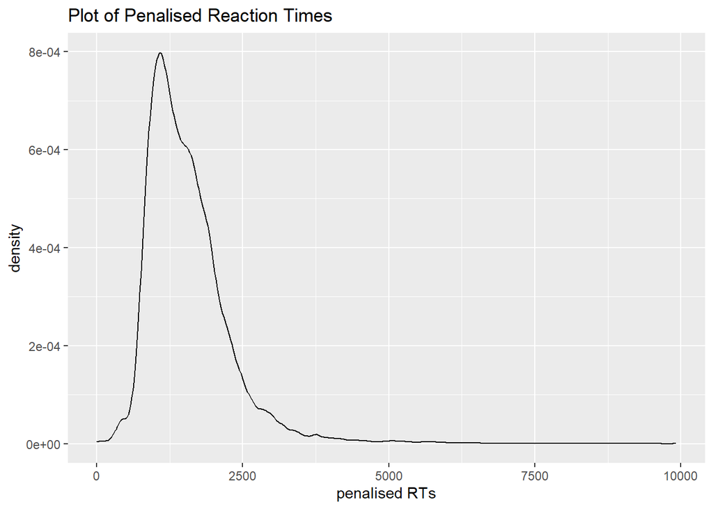

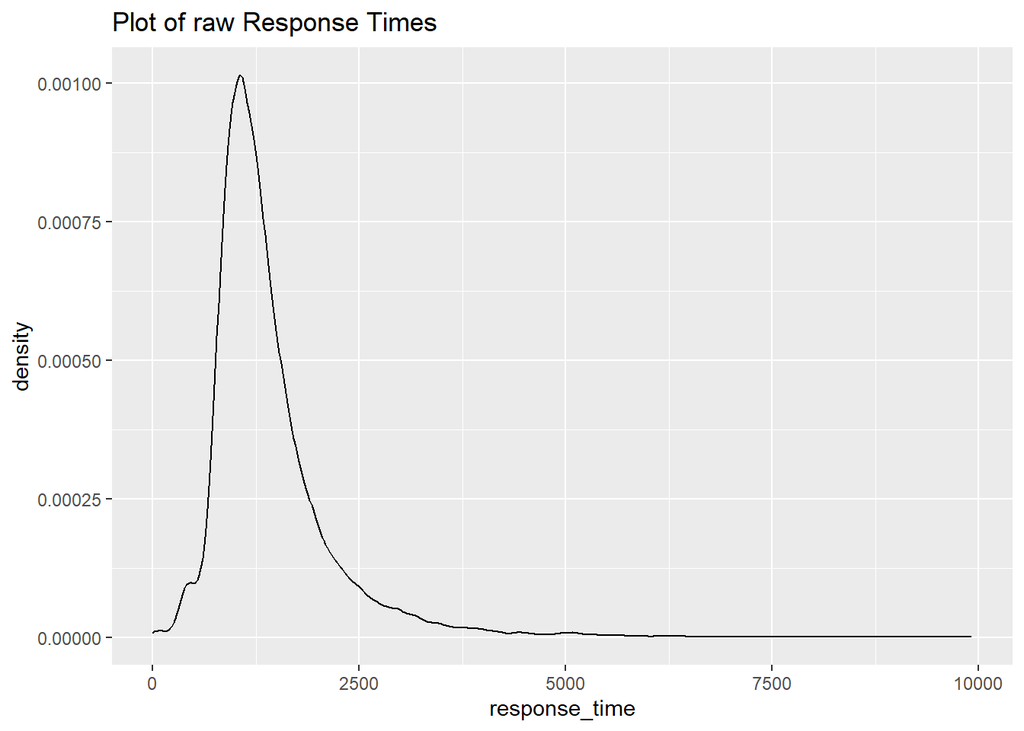

# Prep IAT data: ## separate in- and outgropup Separate ingroup from outgroup based on exposure to Swabian, outgroup consists of other non-standard, vernacular speakers, standard speakers and bilinguals, see data cleaning file

# Prep IAT data:

## separate in- and outgropup

### plots

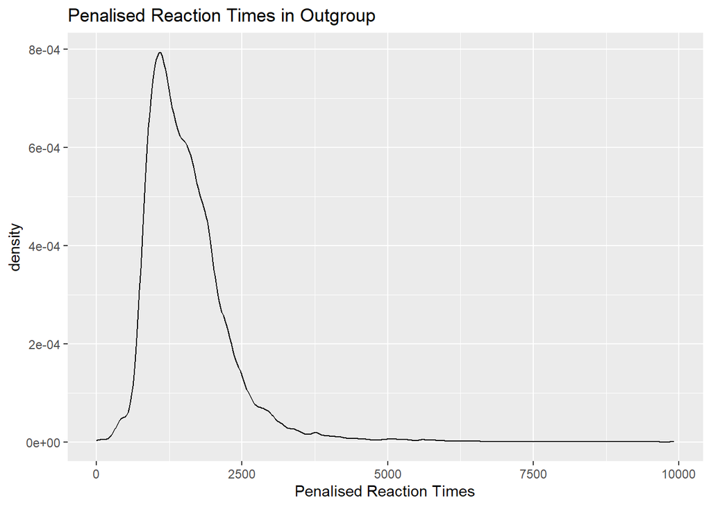

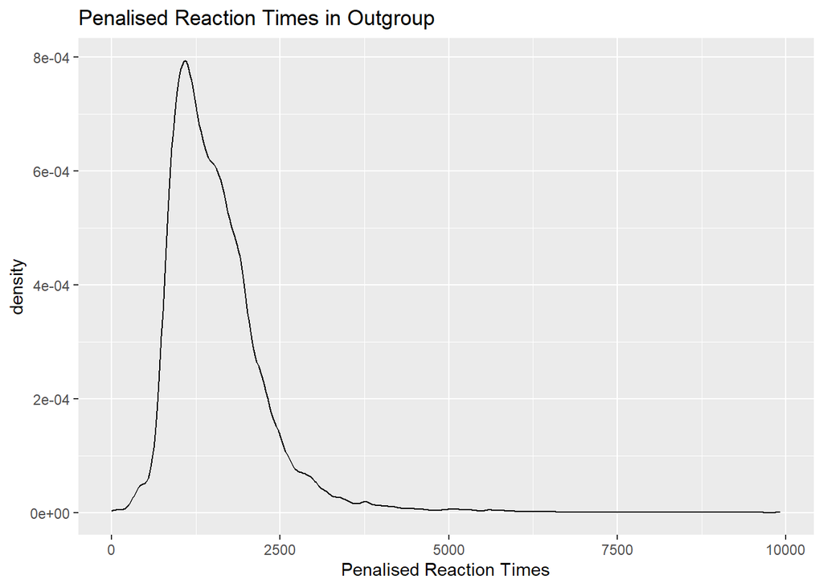

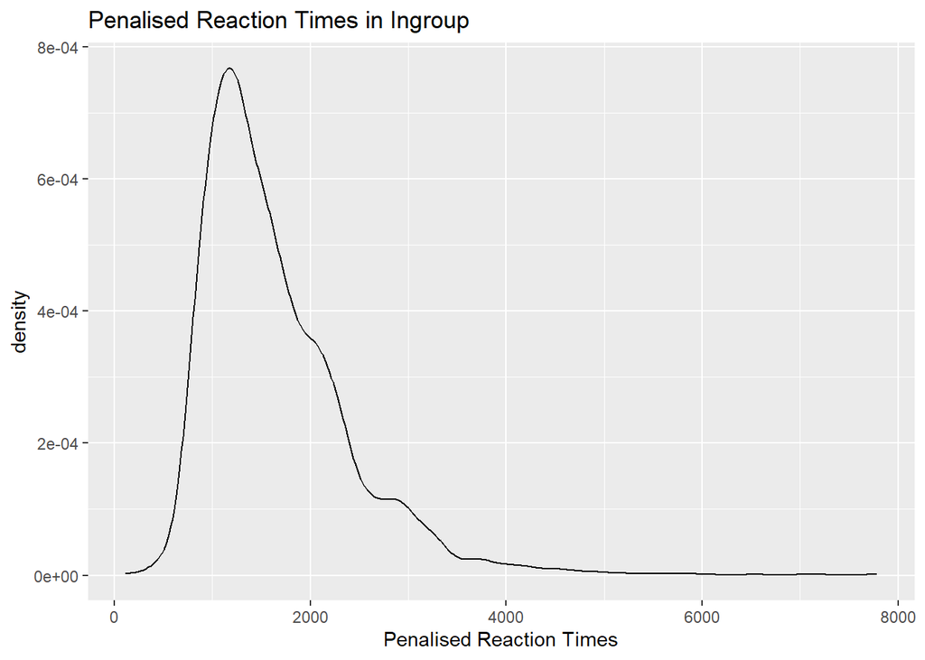

# Prep IAT data: ## descriptives of data sets

```
## [1] 616
```

```
## [1] 538
```

```
## [1] 36
```

```
## # A tibble: 1 × 4
##   `mean(age)` `sd(age)` `min(age)` `max(age)`
##         <dbl>     <dbl>      <dbl>      <dbl>
## 1        45.8      16.4         18         83
```

```
## # A tibble: 4 × 2
##   family_member1_cat.response count
##   <fct>                       <int>
## 1 bilingual                      38
## 2 other                          47
## 3 non_st.outgroup               166
## 4 standard                      287
```

```
## # A tibble: 1 × 4
##   `mean(age)` `sd(age)` `min(age)` `max(age)`
##         <dbl>     <dbl>      <dbl>      <dbl>
## 1        46.0      16.4         18         83
```

```
## # A tibble: 1 × 4
##   `mean(age)` `sd(age)` `min(age)` `max(age)`
##         <dbl>     <dbl>      <dbl>      <dbl>
## 1        44.9      16.4         19         79
```

```
## # A tibble: 4 × 2
##   pp_gender `n_distinct(bilendi_id)`
##   <fct>                        <int>
## 1 divers                           1
## 2 female                         334
## 3 male                           279
## 4 <NA>                             2
```

```
## # A tibble: 3 × 2
##   pp_gender `n_distinct(bilendi_id)`
##   <fct>                        <int>
## 1 divers                           1
## 2 female                         290
## 3 male                           247
```

```
## # A tibble: 2 × 2
##   pp_gender `n_distinct(bilendi_id)`
##   <fct>                        <int>
## 1 female                          19
## 2 male                            17
```

```
## # A tibble: 4 × 2
##   sum_training `n_distinct(bilendi_id)`
##   <fct>                           <int>
## 1 high                              289
## 2 low                               128
## 3 middle                            196
## 4 <NA>                                3
```

```
## # A tibble: 4 × 2
##   sum_training `n_distinct(bilendi_id)`
##   <fct>                           <int>
## 1 high                              258
## 2 low                               110
## 3 middle                            169
## 4 <NA>                                1
```

```
## # A tibble: 5 × 2
##   sum_education   `n_distinct(bilendi_id)`
##   <fct>                              <int>
## 1 high                                 350
## 2 low                                   33
## 3 middle                               152
## 4 other                                  1
## 5 still at school                        2
```

# correlation matrix of data sets

```
##              penal_RTs           age      ideology   populism1   populism2
## penal_RTs  1.000000000  0.1162726545 -0.0491593685 0.008292696 -0.01186507
## age        0.116272655  1.0000000000 -0.0001847734 0.027224360 -0.10717231
## ideology  -0.049159368 -0.0001847734  1.0000000000 0.087012017  0.10185386
## populism1  0.008292696  0.0272243604  0.0870120175 1.000000000  0.42871170
## populism2 -0.011865068 -0.1071723143  0.1018538635 0.428711695  1.00000000
## populism3 -0.023795819 -0.0054521429  0.1603600963 0.399283755  0.43759286
## populism4 -0.034857042 -0.1059965811  0.1165560262 0.296733962  0.31605269
##              populism3   populism4
## penal_RTs -0.023795819 -0.03485704
## age       -0.005452143 -0.10599658
## ideology   0.160360096  0.11655603
## populism1  0.399283755  0.29673396
## populism2  0.437592860  0.31605269
## populism3  1.000000000  0.33863618
## populism4  0.338636181  1.00000000
```

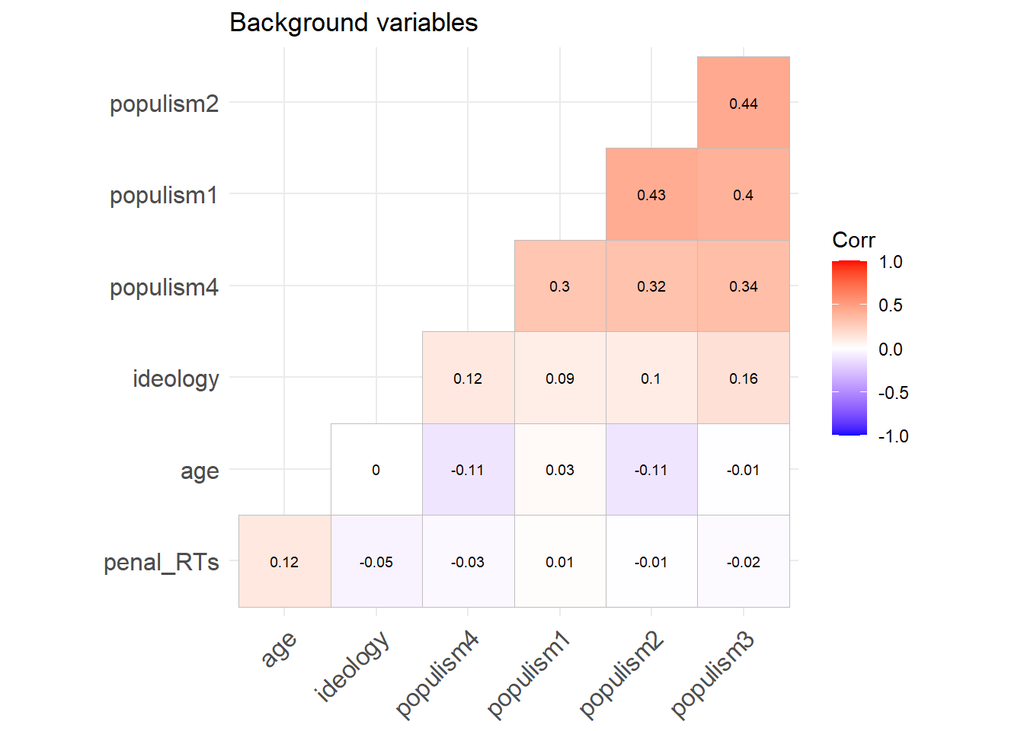

# GLMS Outgroup ## general

```
## Linear mixed model fit by REML. t-tests use Satterthwaite's method [
## lmerModLmerTest]
## Formula: penal_RTs ~ charisma_lang_var * start_iat + trialcount + stim_cat +
##     age + (charisma_lang_var | bilendi_id) + (start_iat | stimulus_ID)
##    Data: Four_Out
## Control: lmerControl(optimizer = "bobyqa", optCtrl = list(maxfun = 2e+05))
##
## REML criterion at convergence: 1003941
##
## Scaled residuals:
##     Min      1Q  Median      3Q     Max
## -6.2899 -0.6202 -0.1215  0.5483 13.5274
##
## Random effects:
##  Groups      Name                              Variance Std.Dev. Corr
##  bilendi_id  (Intercept)                       165563   406.89
##              charisma_lang_varvernacular       113139   336.36   -0.24
##  stimulus_ID (Intercept)                         9054    95.15
##              start_iatvernacular-with Charisma   1030    32.09   -0.35
##  Residual                                      326972   571.81
## Number of obs: 64365, groups:  bilendi_id, 537; stimulus_ID, 303
##
## Fixed effects:
##                                                                 Estimate
## (Intercept)                                                    1690.4921
## charisma_lang_varvernacular                                     560.6201
## start_iatvernacular-with Charisma                               436.9144
## trialcount                                                       -5.7760
## stim_catleadership                                              137.7838
## age                                                               4.7108
## charisma_lang_varvernacular:start_iatvernacular-with Charisma  -980.2611
##                                                               Std. Error
## (Intercept)                                                      57.0804
## charisma_lang_varvernacular                                      25.3004
## start_iatvernacular-with Charisma                                37.7504
## trialcount                                                        0.1304
## stim_catleadership                                               13.0217
## age                                                               1.0461
## charisma_lang_varvernacular:start_iatvernacular-with Charisma    38.4826
##                                                                       df
```

[output cut: 19 more lines]

```
## trialcount                                                    ***
## stim_catleadership                                            ***
## age                                                           ***
## charisma_lang_varvernacular:start_iatvernacular-with Charisma ***
## ---
## Signif. codes:  0 '***' 0.001 '**' 0.01 '*' 0.05 '.' 0.1 ' ' 1
##
## Correlation of Fixed Effects:
##             (Intr) chrs__ str_-C trlcnt stm_ct age
## chrsm_lng_v -0.035
## strt_tvrn-C -0.291  0.309
## trialcount  -0.161 -0.464 -0.311
## stm_ctldrsh -0.168  0.000  0.004  0.000
## age         -0.851  0.000  0.020  0.000  0.001
## chrsm__:_-C -0.026 -0.799 -0.391  0.610  0.000  0.000
```

```
## Type III Analysis of Variance Table with Satterthwaite's method
##                                Sum Sq   Mean Sq NumDF DenDF   F value    Pr(>F)
## charisma_lang_var             6984939   6984939     1   535   21.3625 4.771e-06
## start_iat                      754060    754060     1   536    2.3062    0.1294
## trialcount                  641965583 641965583     1 63035 1963.3672 < 2.2e-16
## stim_cat                     36607868  36607868     1   263  111.9603 < 2.2e-16
## age                           6630711   6630711     1   534   20.2792 8.224e-06
## charisma_lang_var:start_iat 212161189 212161189     1  1350  648.8671 < 2.2e-16
##
## charisma_lang_var           ***
## start_iat
## trialcount                  ***
## stim_cat                    ***
## age                         ***
## charisma_lang_var:start_iat ***
## ---
## Signif. codes:  0 '***' 0.001 '**' 0.01 '*' 0.05 '.' 0.1 ' ' 1
```

```
## Note: D.f. calculations have been disabled because the number of observations exceeds 3000.
## To enable adjustments, add the argument 'pbkrtest.limit = 64365' (or larger)
## [or, globally, 'set emm_options(pbkrtest.limit = 64365)' or larger];
## but be warned that this may result in large computation time and memory use.
```

```
## Note: D.f. calculations have been disabled because the number of observations exceeds 3000.
## To enable adjustments, add the argument 'lmerTest.limit = 64365' (or larger)
## [or, globally, 'set emm_options(lmerTest.limit = 64365)' or larger];
## but be warned that this may result in large computation time and memory use.
```

```
## $emmeans
##  charisma_lang_var start_iat                emmean   SE  df asymp.LCL asymp.UCL
##  standard          standard-with Charisma     1309 27.7 Inf      1255      1363
##  vernacular        standard-with Charisma     1870 30.9 Inf      1809      1930
##  standard          vernacular-with Charisma   1746 25.7 Inf      1696      1796
##  vernacular        vernacular-with Charisma   1326 28.6 Inf      1270      1383
##
## Results are averaged over the levels of: stim_cat
## Degrees-of-freedom method: asymptotic
## Confidence level used: 0.95
##
## $contrasts
##  contrast
##  (standard standard-with Charisma) - (vernacular standard-with Charisma)
##  (standard standard-with Charisma) - (standard vernacular-with Charisma)
##  (standard standard-with Charisma) - (vernacular vernacular-with Charisma)
##  (vernacular standard-with Charisma) - (standard vernacular-with Charisma)
##  (vernacular standard-with Charisma) - (vernacular vernacular-with Charisma)
##  (standard vernacular-with Charisma) - (vernacular vernacular-with Charisma)
##  estimate   SE  df z.ratio p.value
##    -560.6 25.3 Inf -22.159  <.0001
##    -436.9 37.8 Inf -11.574  <.0001
##     -17.3 38.0 Inf  -0.454  0.9688
##     123.7 38.4 Inf   3.222  0.0070
##     543.3 42.1 Inf  12.910  <.0001
##     419.6 23.8 Inf  17.646  <.0001
##
## Results are averaged over the levels of: stim_cat
## Degrees-of-freedom method: asymptotic
## P value adjustment: tukey method for comparing a family of 4 estimates
```

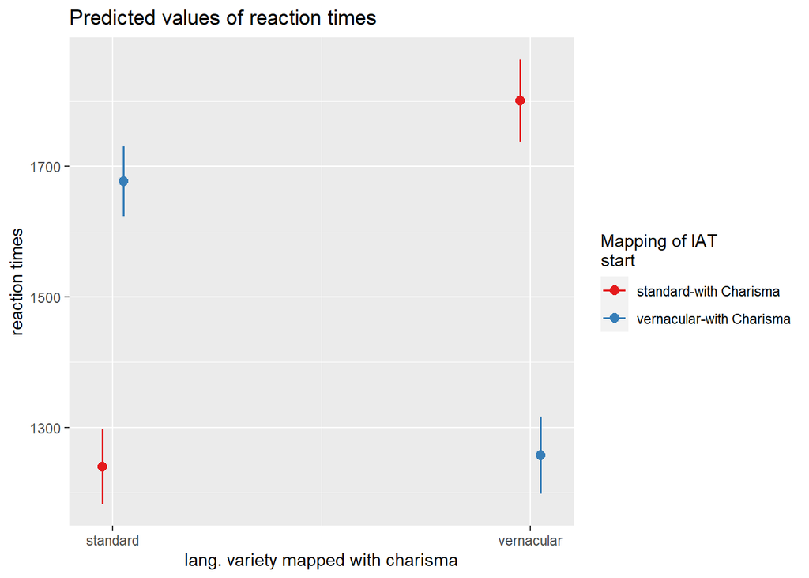

```
## Linear mixed model fit by REML. t-tests use Satterthwaite's method [
## lmerModLmerTest]
## Formula: penal_RTs ~ charisma_lang_var * start_iat + trialcount + age +
##     leadership_lang_var + stim_cat + (charisma_lang_var | bilendi_id) +
##     (start_iat | stimulus_ID)
##    Data: Four_Out
## Control: lmerControl(optimizer = "bobyqa", optCtrl = list(maxfun = 2e+05))
##
## REML criterion at convergence: 1003928
##
## Scaled residuals:
##     Min      1Q  Median      3Q     Max
## -6.2906 -0.6201 -0.1212  0.5483 13.5283
##
## Random effects:
##  Groups      Name                            Variance Std.Dev. Corr
##  bilendi_id  (Intercept)                     212266   460.72
##              charisma_lang_varstandard       113139   336.36   -0.52
##  stimulus_ID (Intercept)                       7964    89.24
##              start_iatstandard-with Charisma   1029    32.08   0.01
##  Residual                                    326970   571.81
## Number of obs: 64365, groups:  bilendi_id, 537; stimulus_ID, 303
##
## Fixed effects:
##                                                             Estimate Std. Error
## (Intercept)                                                1677.0235    59.0257
## charisma_lang_varstandard                                   419.6376    23.7809
## start_iatstandard-with Charisma                             541.9483    42.1405
## trialcount                                                   -5.7760     0.1304
## age                                                           4.7582     1.0439
## leadership_lang_var2                                         68.5061    34.8779
## stim_catleadership                                          137.6708    13.0313
## charisma_lang_varstandard:start_iatstandard-with Charisma  -980.2547    38.4825
##                                                                   df t value
## (Intercept)                                                 662.6639  28.412
## charisma_lang_varstandard                                   932.7660  17.646
## start_iatstandard-with Charisma                             624.1773  12.861
## trialcount                                                63035.5050 -44.310
## age                                                         533.0047   4.558
## leadership_lang_var2                                        542.8836   1.964
```

[output cut: 8 more lines]

```
## leadership_lang_var2                                          0.05 .
## stim_catleadership                                         < 2e-16 ***
## charisma_lang_varstandard:start_iatstandard-with Charisma  < 2e-16 ***
## ---
## Signif. codes:  0 '***' 0.001 '**' 0.01 '*' 0.05 '.' 0.1 ' ' 1
##
## Correlation of Fixed Effects:
##             (Intr) chrs__ str_-C trlcnt age    ldr__2 stm_ct
## chrsm_lng_v -0.135
## strt_tstn-C -0.239  0.434
## trialcount  -0.156 -0.493 -0.278
## age         -0.816  0.000 -0.019  0.000
## ldrshp_ln_2 -0.273  0.000 -0.017  0.000  0.033
## stm_ctldrsh -0.159  0.000 -0.004  0.000  0.000 -0.004
## chrsm__:_-C  0.036 -0.768 -0.568  0.610  0.000  0.000  0.000
```

# Outgroup

## descriptives of political background measures

*voting behaviour & ideology & populism*

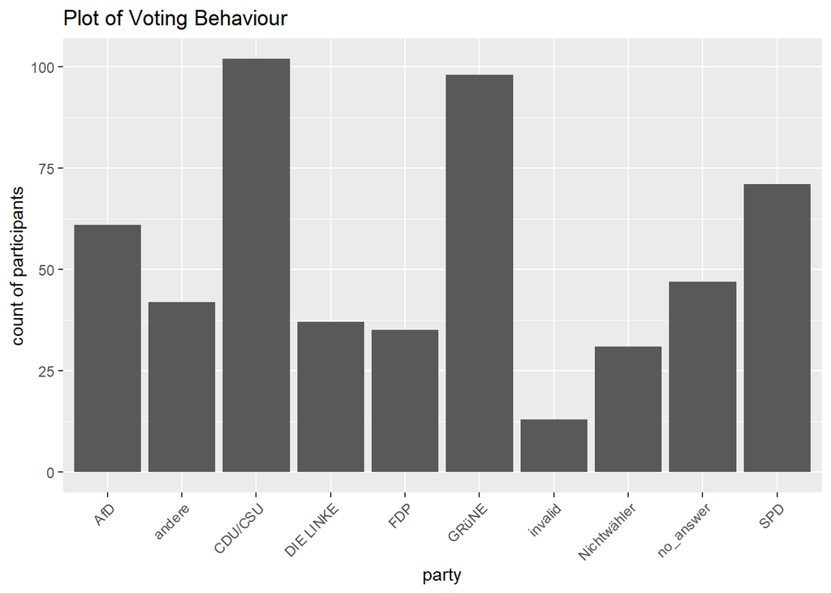

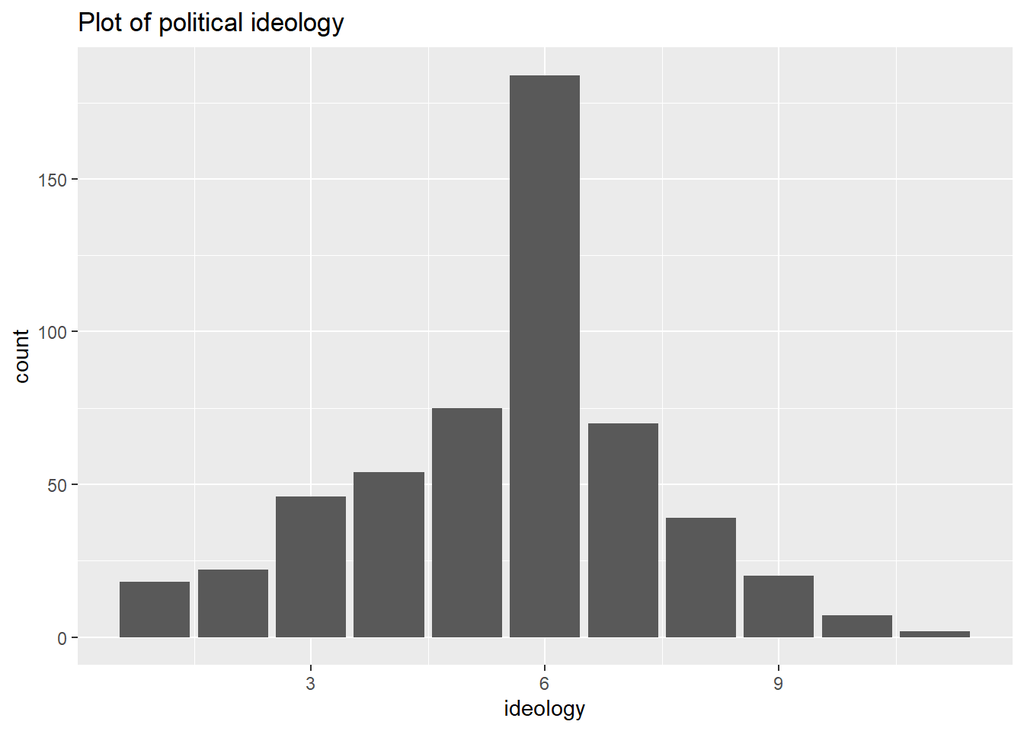

```
## # A tibble: 1 × 16
##   `mean(populism1)` `sd(populism1)` `min(populism1)` `max(populism1)`
##               <dbl>           <dbl>            <dbl>            <dbl>
## 1              3.44            1.08                1                5
## # ℹ 12 more variables: `mean(populism2)` <dbl>, `sd(populism2)` <dbl>,
## #   `min(populism2)` <dbl>, `max(populism2)` <dbl>, `mean(populism3)` <dbl>,
## #   `sd(populism3)` <dbl>, `min(populism3)` <dbl>, `max(populism3)` <dbl>,
## #   `mean(populism4)` <dbl>, `sd(populism4)` <dbl>, `min(populism4)` <dbl>,
## #   `max(populism4)` <dbl>
```

# Outgroup

## Populism & PCA

*PCA shows difference of populism 4 item in comparison to items populism 1, 2, 3* Item populism 4 from elite dimension of Akkerman et al. 2014, populism 1-3 from populism dimension

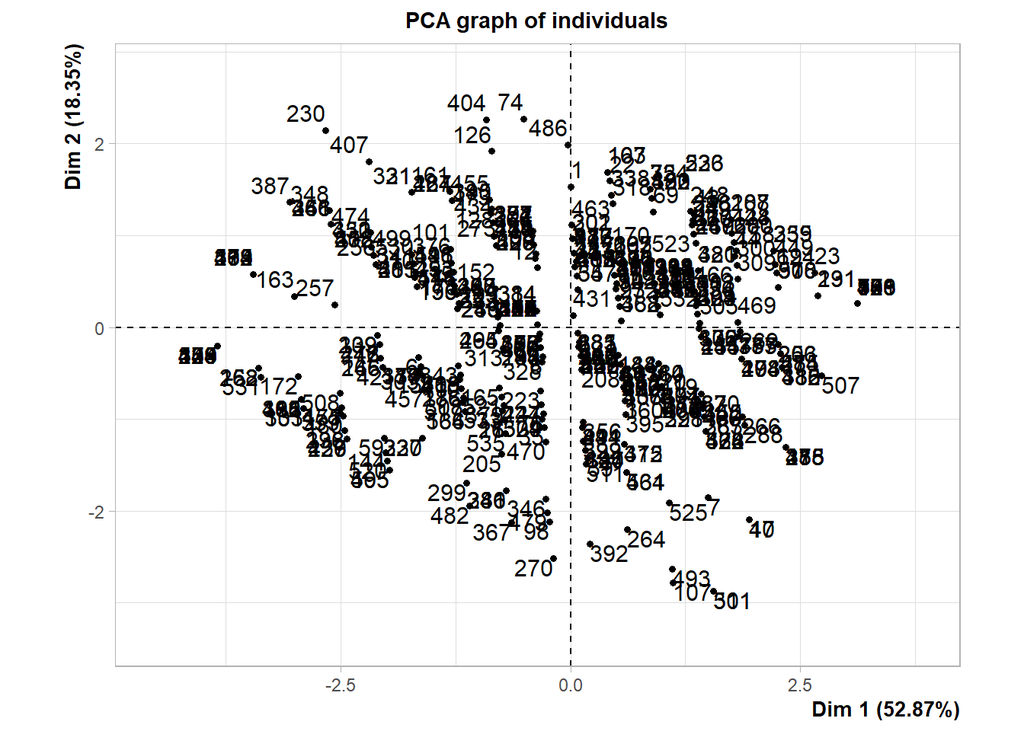

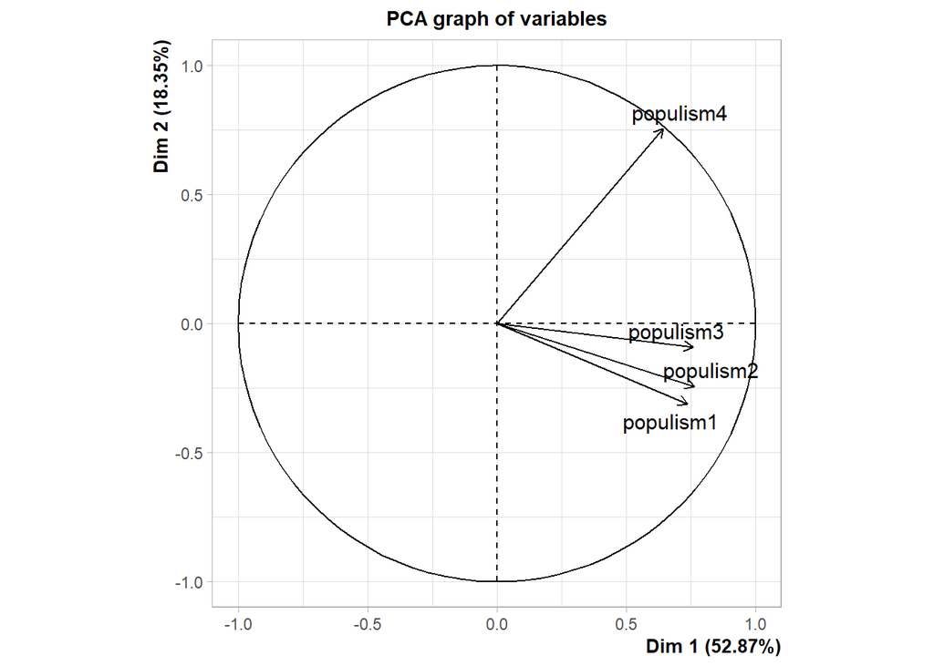

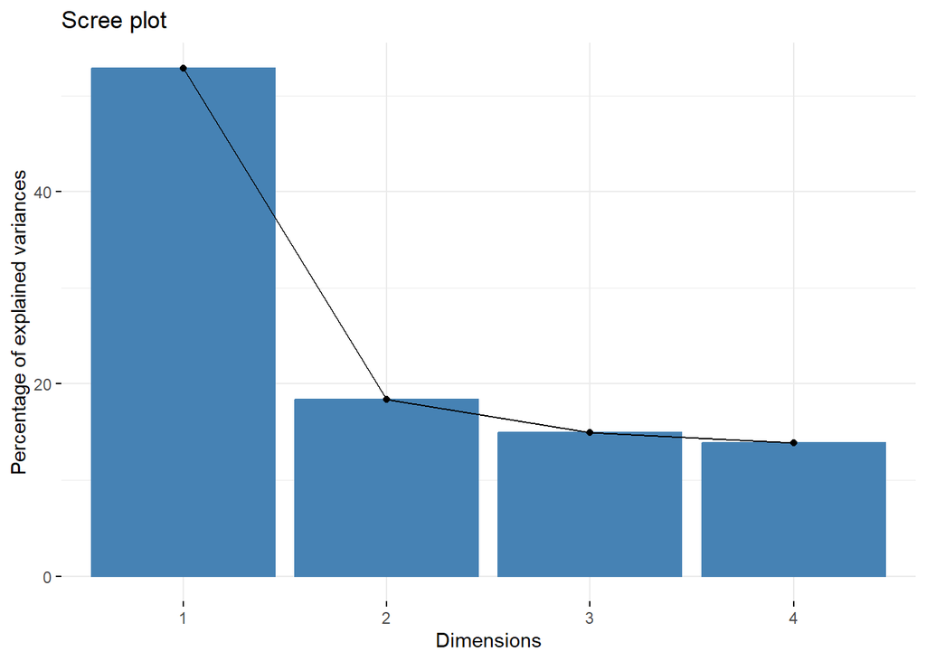

```
##               Dim.1      Dim.2      Dim.3       Dim.4
## populism1 0.7365805 -0.3121794  0.5485245  0.24313372
## populism2 0.7634562 -0.2434350 -0.1225943 -0.58552944
## populism3 0.7586429 -0.0914356 -0.5151814  0.38818628
## populism4 0.6432026  0.7542946  0.1250021 -0.04128756
```

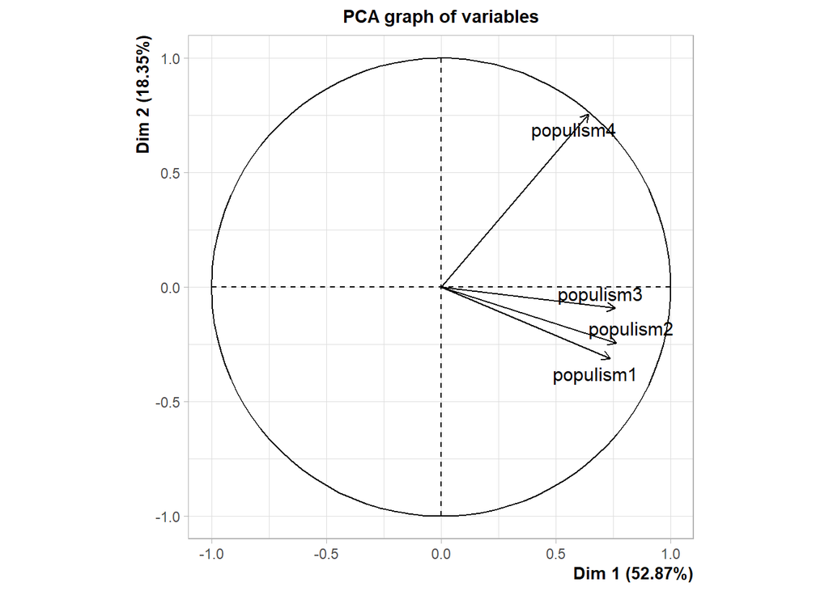

```
##
## Call:
## PCA(X = PCA_pop_data[, 2:5], scale.unit = TRUE, ncp = 2, graph = T)
##
##
## Eigenvalues
##                        Dim.1   Dim.2   Dim.3   Dim.4
## Variance               2.115   0.734   0.597   0.554
## % of var.             52.867  18.351  14.924  13.859
## Cumulative % of var.  52.867  71.218  86.141 100.000
##
## Individuals (the 10 first)
##               Dist    Dim.1    ctr   cos2    Dim.2    ctr   cos2
## 1         |  2.368 |  0.005  0.000  0.000 |  1.530  0.594  0.418 |
## 2         |  2.777 | -2.166  0.413  0.608 |  0.879  0.196  0.100 |
## 3         |  1.759 |  0.590  0.031  0.112 | -0.800  0.162  0.207 |
## 4         |  1.413 |  1.383  0.168  0.958 |  0.143  0.005  0.010 |
## 5         |  3.141 |  3.125  0.860  0.990 |  0.259  0.017  0.007 |
## 6         |  1.890 | -1.656  0.242  0.767 | -0.330  0.028  0.031 |
## 7         |  2.591 |  1.499  0.198  0.335 | -1.850  0.868  0.510 |
## 8         |  1.944 | -0.301  0.008  0.024 | -0.318  0.026  0.027 |
## 9         |  0.836 |  0.034  0.000  0.002 |  0.810  0.167  0.939 |
## 10        |  3.141 |  3.125  0.860  0.990 |  0.259  0.017  0.007 |
##
## Variables
##              Dim.1    ctr   cos2    Dim.2    ctr   cos2
## populism1 |  0.737 25.657  0.543 | -0.312 13.277  0.097 |
## populism2 |  0.763 27.563  0.583 | -0.243  8.073  0.059 |
## populism3 |  0.759 27.217  0.576 | -0.091  1.139  0.008 |
## populism4 |  0.643 19.564  0.414 |  0.754 77.511  0.569 |
```

```
## $Dim.1
##
## Link between the variable and the continuous variables (R-square)
## =================================================================================
##           correlation       p.value
## populism2   0.7634562 1.197054e-103
## populism3   0.7586429 1.269205e-101
## populism1   0.7365805  6.476874e-93
## populism4   0.6432026  4.991777e-64
##
## $Dim.2
##
## Link between the variable and the continuous variables (R-square)
## =================================================================================
##           correlation       p.value
## populism4   0.7542946 7.812409e-100
## populism3  -0.0914356  3.414437e-02
## populism2  -0.2434350  1.102087e-08
## populism1  -0.3121794  1.329712e-13
```

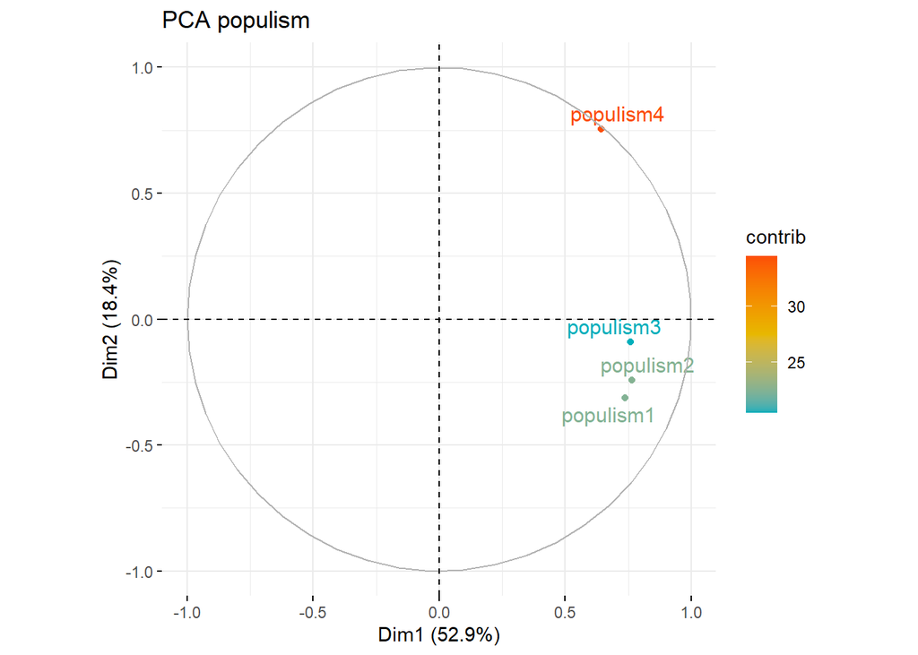

# Outgroup ## Populism & PCA

*new dimension reduction variable for populism after PCA*

# Outgroup

## prep populism

create 2 dummy variables for populism a) mean of populism scores items 1-3, but exclude pop 4 -> PCA shows very different b) use principal component 1 as dummy

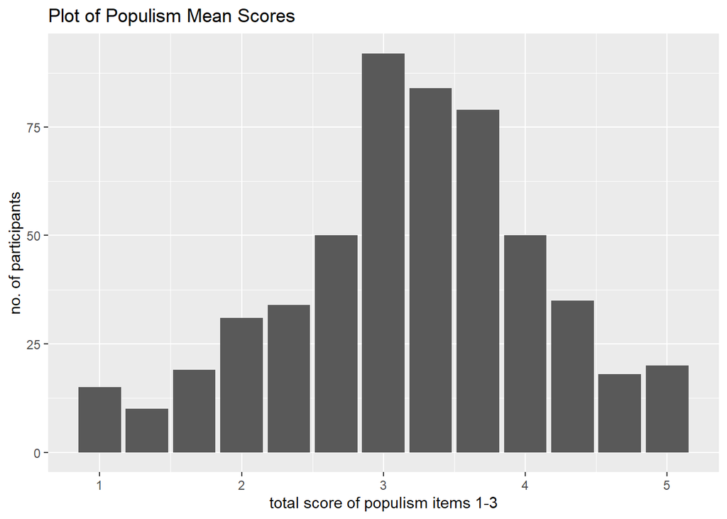

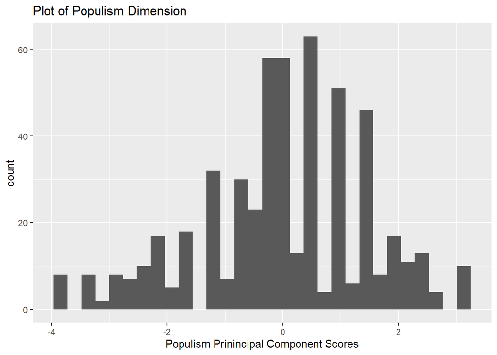

# Outgroup ## prep all political background measures scale political bckgr variables

# Outgroup

## prep populism

- create populism subsets*

## political background measures

### GLMs: Max model

```
## Linear mixed model fit by REML. t-tests use Satterthwaite's method [
## lmerModLmerTest]
## Formula: penal_RTs ~ charisma_lang_var * start_iat + trialcount + stim_cat +
##     age + leadership_lang_var + populism_dim:charisma_lang_var +
##     ideology:charisma_lang_var + voting_behaviour:charisma_lang_var +
##     (charisma_lang_var | bilendi_id) + (start_iat | stimulus_ID)
##    Data: Four_Out
## Control: lmerControl(optimizer = "bobyqa", optCtrl = list(maxfun = 2e+05))
##
## REML criterion at convergence: 1003690
##
## Scaled residuals:
##    Min     1Q Median     3Q    Max
## -6.293 -0.620 -0.121  0.548 13.530
##
## Random effects:
##  Groups      Name                              Variance Std.Dev. Corr
##  bilendi_id  (Intercept)                       209650   457.88
##              charisma_lang_varstandard         112856   335.94   -0.52
##  stimulus_ID (Intercept)                         9062    95.19
##              start_iatvernacular-with Charisma   1030    32.09   -0.35
##  Residual                                      326970   571.81
## Number of obs: 64365, groups:  bilendi_id, 537; stimulus_ID, 303
##
## Fixed effects:
##                                                               Estimate
## (Intercept)                                                  2197.1161
## charisma_lang_varstandard                                    -506.4416
## start_iatvernacular-with Charisma                            -541.1279
## trialcount                                                     -5.7761
## stim_catleadership                                            137.6692
## age                                                             4.7182
## leadership_lang_var2                                           59.4997
## charisma_lang_varstandard:start_iatvernacular-with Charisma   980.4615
## charisma_lang_varvernacular:populism_dim                        8.8397
## charisma_lang_varstandard:populism_dim                         -8.5072
## charisma_lang_varvernacular:ideology                          -28.9908
## charisma_lang_varstandard:ideology                            -24.9169
## charisma_lang_varvernacular:voting_behaviourandere            -18.9695
## charisma_lang_varstandard:voting_behaviourandere              -89.1664
```

[output cut: 96 more lines]

```
## charisma_lang_varstandard:voting_behaviourDIE LINKE           0.2123
## charisma_lang_varvernacular:voting_behaviourFDP               0.1774
## charisma_lang_varstandard:voting_behaviourFDP                 0.2506
## charisma_lang_varvernacular:voting_behaviourGRüNE             0.2642
## charisma_lang_varstandard:voting_behaviourGRüNE               0.6677
## charisma_lang_varvernacular:voting_behaviourinvalid           0.6212
## charisma_lang_varstandard:voting_behaviourinvalid             0.9695
## charisma_lang_varvernacular:voting_behaviourNichtwähler       0.5674
## charisma_lang_varstandard:voting_behaviourNichtwähler         0.5600
## charisma_lang_varvernacular:voting_behaviourno_answer         0.4952
## charisma_lang_varstandard:voting_behaviourno_answer           0.9155
## charisma_lang_varvernacular:voting_behaviourSPD               0.1979
## charisma_lang_varstandard:voting_behaviourSPD                 0.8837
## ---
## Signif. codes:  0 '***' 0.001 '**' 0.01 '*' 0.05 '.' 0.1 ' ' 1
```

```
##
## Correlation matrix not shown by default, as p = 30 > 12.
## Use print(x, correlation=TRUE)  or
##     vcov(x)        if you need it
```

```
## Type III Analysis of Variance Table with Satterthwaite's method
##                                       Sum Sq   Mean Sq NumDF DenDF   F value
## charisma_lang_var                      34931     34931     1   524    0.1068
## start_iat                             687431    687431     1   524    2.1024
## trialcount                         641970330 641970330     1 63035 1963.3938
## stim_cat                            36501776  36501776     1   263  111.6366
## age                                  6379210   6379210     1   522   19.5101
## leadership_lang_var                   935803    935803     1   532    2.8620
## charisma_lang_var:start_iat        210700356 210700356     1  1311  644.4033
## charisma_lang_var:populism_dim        771294    385647     2   522    1.1795
## charisma_lang_var:ideology            541379    270689     2   522    0.8279
## charisma_lang_var:voting_behaviour   6062161    336787    18   522    1.0300
##                                       Pr(>F)
## charisma_lang_var                    0.74391
## start_iat                            0.14766
## trialcount                         < 2.2e-16 ***
## stim_cat                           < 2.2e-16 ***
## age                                1.217e-05 ***
## leadership_lang_var                  0.09128 .
## charisma_lang_var:start_iat        < 2.2e-16 ***
## charisma_lang_var:populism_dim       0.30826
## charisma_lang_var:ideology           0.43755
## charisma_lang_var:voting_behaviour   0.42344
## ---
## Signif. codes:  0 '***' 0.001 '**' 0.01 '*' 0.05 '.' 0.1 ' ' 1
```

## political background measures

### focus: populism

*no impact of neither populism measure, populism_all or populism_dim

```
## Linear mixed model fit by REML. t-tests use Satterthwaite's method [
## lmerModLmerTest]
## Formula:
## penal_RTs ~ charisma_lang_var * populism_all + start_iat + trialcount +
##     age + leadership_lang_var + (charisma_lang_var | bilendi_id) +
##     (start_iat | stimulus_ID)
##    Data: Four_Out
## Control: lmerControl(optimizer = "bobyqa", optCtrl = list(maxfun = 2e+05))
##
## REML criterion at convergence: 1004518
##
## Scaled residuals:
##     Min      1Q  Median      3Q     Max
## -6.3944 -0.6195 -0.1255  0.5498 13.4543
##
## Random effects:
##  Groups      Name                              Variance Std.Dev. Corr
##  bilendi_id  (Intercept)                       177991   421.89
##              charisma_lang_varvernacular       261557   511.43   -0.36
##  stimulus_ID (Intercept)                        11744   108.37
##              start_iatvernacular-with Charisma   1077    32.81   -0.05
##  Residual                                      327354   572.15
## Number of obs: 64365, groups:  bilendi_id, 537; stimulus_ID, 303
##
## Fixed effects:
##                                           Estimate Std. Error        df t value
## (Intercept)                              1850.4712    89.3841  523.7143  20.702
## charisma_lang_varvernacular               -13.9352    82.7187  410.7463  -0.168
## populism_all                              -14.2828    20.4498  409.5477  -0.698
## start_iatvernacular-with Charisma          99.6184    34.7606  542.4559   2.866
## trialcount                                 -4.6195     0.1158 8462.3726 -39.905
## age                                         4.7366     1.0454  531.9962   4.531
## leadership_lang_var2                       70.9891    34.9205  542.9575   2.033
## charisma_lang_varvernacular:populism_all   16.7599    24.9060  410.6844   0.673
##                                          Pr(>|t|)
## (Intercept)                               < 2e-16 ***
## charisma_lang_varvernacular               0.86630
## populism_all                              0.48530
## start_iatvernacular-with Charisma         0.00432 **
## trialcount                                < 2e-16 ***
## age                                      7.26e-06 ***
## leadership_lang_var2                      0.04255 *
## charisma_lang_varvernacular:populism_all  0.50137
## ---
## Signif. codes:  0 '***' 0.001 '**' 0.01 '*' 0.05 '.' 0.1 ' ' 1
##
## Correlation of Fixed Effects:
##             (Intr) chrs__ pplsm_ str_-C trlcnt age    ldr__2
## chrsm_lng_v -0.283
## populism_ll -0.750  0.357
## strt_tvrn-C -0.208 -0.001  0.001
## trialcount  -0.130  0.010  0.000 -0.117
## age         -0.574  0.000  0.035  0.023  0.000
## ldrshp_ln_2 -0.188  0.000 -0.001  0.021  0.000  0.033
## chrsm_ln_:_  0.271 -0.962 -0.371  0.000  0.000  0.000  0.000
```

```
## Type III Analysis of Variance Table with Satterthwaite's method
##                                   Sum Sq   Mean Sq NumDF  DenDF   F value
## charisma_lang_var                   9290      9290     1  410.7    0.0284
## populism_all                       29684     29684     1  464.3    0.0907
## start_iat                        2688586   2688586     1  542.5    8.2131
## trialcount                     521293037 521293037     1 8462.4 1592.4426
## age                              6719693   6719693     1  532.0   20.5273
## leadership_lang_var              1352821   1352821     1  543.0    4.1326
## charisma_lang_var:populism_all    148236    148236     1  410.7    0.4528
##                                   Pr(>F)
## charisma_lang_var                0.86630
## populism_all                     0.76345
## start_iat                        0.00432 **
## trialcount                     < 2.2e-16 ***
## age                            7.265e-06 ***
## leadership_lang_var              0.04255 *
## charisma_lang_var:populism_all   0.50137
## ---
## Signif. codes:  0 '***' 0.001 '**' 0.01 '*' 0.05 '.' 0.1 ' ' 1
```

```
## Linear mixed model fit by REML. t-tests use Satterthwaite's method [
## lmerModLmerTest]
## Formula:
## penal_RTs ~ charisma_lang_var * populism_dim + trialcount + start_iat +
##     age + leadership_lang_var + (charisma_lang_var | bilendi_id) +
##     (start_iat | stimulus_ID)
##    Data: Four_Out
## Control: lmerControl(optimizer = "bobyqa", optCtrl = list(maxfun = 2e+05))
##
## REML criterion at convergence: 1004519
##
## Scaled residuals:
##     Min      1Q  Median      3Q     Max
## -6.3945 -0.6195 -0.1254  0.5500 13.4546
##
## Random effects:
##  Groups      Name                              Variance Std.Dev. Corr
##  bilendi_id  (Intercept)                       177699   421.54
##              charisma_lang_varvernacular       261435   511.31   -0.36
##  stimulus_ID (Intercept)                        11745   108.37
##              start_iatvernacular-with Charisma   1077    32.81   -0.05
##  Residual                                      327355   572.15
## Number of obs: 64365, groups:  bilendi_id, 537; stimulus_ID, 303
##
## Fixed effects:
##                                           Estimate Std. Error        df t value
## (Intercept)                              1805.8655    59.1857  595.0601  30.512
## charisma_lang_varvernacular                39.6238    22.5384  411.5115   1.758
## populism_dim                              -12.8574    12.7244  410.5305  -1.010
## trialcount                                 -4.6192     0.1158 8456.0419 -39.904
## start_iatvernacular-with Charisma         100.3465    34.7518  542.5299   2.888
## age                                         4.7026     1.0464  531.9700   4.494
## leadership_lang_var2                       71.2153    34.9097  542.9556   2.040
## charisma_lang_varvernacular:populism_dim   12.4504    15.4884  410.6293   0.804
##                                          Pr(>|t|)
## (Intercept)                               < 2e-16 ***
## charisma_lang_varvernacular               0.07948 .
## populism_dim                              0.31287
## trialcount                                < 2e-16 ***
## start_iatvernacular-with Charisma         0.00404 **
## age                                      8.58e-06 ***
## leadership_lang_var2                      0.04184 *
## charisma_lang_varvernacular:populism_dim  0.42195
## ---
## Signif. codes:  0 '***' 0.001 '**' 0.01 '*' 0.05 '.' 0.1 ' ' 1
##
## Correlation of Fixed Effects:
##             (Intr) chrs__ pplsm_ trlcnt str_-C age    ldr__2
## chrsm_lng_v -0.123
## populism_dm -0.047  0.000
## trialcount  -0.196  0.037  0.000
## strt_tvrn-C -0.313 -0.004  0.003 -0.118
## age         -0.829  0.000  0.058  0.000  0.023
## ldrshp_ln_2 -0.285  0.000 -0.006  0.000  0.021  0.033
## chrsm_ln_:_  0.000  0.000 -0.370 -0.001  0.000  0.000  0.000
```

```
## Type III Analysis of Variance Table with Satterthwaite's method
##                                   Sum Sq   Mean Sq NumDF  DenDF   F value
## charisma_lang_var                1011770   1011770     1  411.5    3.0907
## populism_dim                       96612     96612     1  464.1    0.2951
## trialcount                     521269096 521269096     1 8456.0 1592.3683
## start_iat                        2729403   2729403     1  542.5    8.3378
## age                              6611492   6611492     1  532.0   20.1967
## leadership_lang_var              1362296   1362296     1  543.0    4.1615
## charisma_lang_var:populism_dim    211530    211530     1  410.6    0.6462
##                                   Pr(>F)
## charisma_lang_var               0.079482 .
## populism_dim                    0.587213
## trialcount                     < 2.2e-16 ***
## start_iat                       0.004038 **
## age                            8.579e-06 ***
## leadership_lang_var             0.041835 *
## charisma_lang_var:populism_dim  0.421946
## ---
## Signif. codes:  0 '***' 0.001 '**' 0.01 '*' 0.05 '.' 0.1 ' ' 1
```

## political background measures

### populism

*subset analysis* difference between 2nd blocks (charisma_lang_var*start_iat), i.e.impact of vernacular when starting with standard-with Charisma vs. impact of standard variety when starting with vernacular-with Charisma) is significant in low populism subset but not significant in high populism subset

```
## Linear mixed model fit by REML. t-tests use Satterthwaite's method [
## lmerModLmerTest]
## Formula: penal_RTs ~ charisma_lang_var * start_iat + trialcount + age +
##     leadership_lang_var + (charisma_lang_var | bilendi_id) +
##     (start_iat | stimulus_ID)
##    Data: Four_Out_high_pop
## Control: lmerControl(optimizer = "bobyqa", optCtrl = list(maxfun = 2e+05))
##
## REML criterion at convergence: 534720.6
##
## Scaled residuals:
##     Min      1Q  Median      3Q     Max
## -6.3516 -0.6123 -0.1105  0.5567 13.5692
##
## Random effects:
##  Groups      Name                            Variance Std.Dev. Corr
##  stimulus_ID (Intercept)                      13406   115.78
##              start_iatstandard-with Charisma   2523    50.23   -0.39
##  bilendi_id  (Intercept)                     273207   522.69
##              charisma_lang_varstandard       126365   355.48   -0.55
##  Residual                                    325913   570.89
## Number of obs: 34272, groups:  stimulus_ID, 303; bilendi_id, 286
##
## Fixed effects:
##                                                             Estimate Std. Error
## (Intercept)                                                1826.0826    87.4038
## charisma_lang_varstandard                                   386.4869    33.9133
## start_iatstandard-with Charisma                             504.6813    64.7677
## trialcount                                                   -5.4238     0.1786
## age                                                           3.7395     1.6015
## leadership_lang_var2                                         42.9332    52.8197
## charisma_lang_varstandard:start_iatstandard-with Charisma  -935.7622    54.4602
##                                                                   df t value
## (Intercept)                                                 335.2963  20.892
## charisma_lang_varstandard                                   471.5648  11.396
## start_iatstandard-with Charisma                             320.0321   7.792
## trialcount                                                33475.9056 -30.367
## age                                                         282.1041   2.335
## leadership_lang_var2                                        285.9945   0.813
## charisma_lang_varstandard:start_iatstandard-with Charisma   666.8867 -17.182
##                                                           Pr(>|t|)
## (Intercept)                                                < 2e-16 ***
## charisma_lang_varstandard                                  < 2e-16 ***
## start_iatstandard-with Charisma                           9.29e-14 ***
## trialcount                                                 < 2e-16 ***
## age                                                         0.0202 *
## leadership_lang_var2                                        0.4170
## charisma_lang_varstandard:start_iatstandard-with Charisma  < 2e-16 ***
## ---
## Signif. codes:  0 '***' 0.001 '**' 0.01 '*' 0.05 '.' 0.1 ' ' 1
##
## Correlation of Fixed Effects:
##             (Intr) chrs__ str_-C trlcnt age    ldr__2
## chrsm_lng_v -0.167
## strt_tstn-C -0.264  0.435
## trialcount  -0.144 -0.474 -0.248
## age         -0.819  0.000 -0.018  0.000
## ldrshp_ln_2 -0.258  0.000 -0.026  0.000  0.003
## chrsm__:_-C  0.062 -0.763 -0.575  0.590  0.000  0.000
```

```
## Type III Analysis of Variance Table with Satterthwaite's method
##                                Sum Sq   Mean Sq NumDF DenDF  F value    Pr(>F)
## charisma_lang_var             4469834   4469834     1   284  13.7148 0.0002557
## start_iat                      151797    151797     1   283   0.4658 0.4955017
## trialcount                  300533568 300533568     1 33476 922.1279 < 2.2e-16
## age                           1776927   1776927     1   282   5.4521 0.0202457
## leadership_lang_var            215326    215326     1   286   0.6607 0.4169944
## charisma_lang_var:start_iat  96221934  96221934     1   667 295.2380 < 2.2e-16
##
## charisma_lang_var           ***
## start_iat
## trialcount                  ***
## age                         *
## leadership_lang_var
## charisma_lang_var:start_iat ***
## ---
## Signif. codes:  0 '***' 0.001 '**' 0.01 '*' 0.05 '.' 0.1 ' ' 1
```

```
## Note: D.f. calculations have been disabled because the number of observations exceeds 3000.
## To enable adjustments, add the argument 'pbkrtest.limit = 34272' (or larger)
## [or, globally, 'set emm_options(pbkrtest.limit = 34272)' or larger];
## but be warned that this may result in large computation time and memory use.
```

```
## Note: D.f. calculations have been disabled because the number of observations exceeds 3000.
## To enable adjustments, add the argument 'lmerTest.limit = 34272' (or larger)
## [or, globally, 'set emm_options(lmerTest.limit = 34272)' or larger];
## but be warned that this may result in large computation time and memory use.
```

```
## $emmeans
##  charisma_lang_var start_iat                emmean   SE  df asymp.LCL asymp.UCL
##  vernacular        vernacular-with Charisma   1389 44.0 Inf      1303      1476
##  standard          vernacular-with Charisma   1776 37.9 Inf      1702      1850
##  vernacular        standard-with Charisma     1894 47.1 Inf      1802      1987
##  standard          standard-with Charisma     1345 40.4 Inf      1266      1424
##
## Results are averaged over the levels of: leadership_lang_var
## Degrees-of-freedom method: asymptotic
## Confidence level used: 0.95
##
## $contrasts
##  contrast
##  (vernacular vernacular-with Charisma) - (standard vernacular-with Charisma)
##  (vernacular vernacular-with Charisma) - (vernacular standard-with Charisma)
##  (vernacular vernacular-with Charisma) - (standard standard-with Charisma)
##  (standard vernacular-with Charisma) - (vernacular standard-with Charisma)
##  (standard vernacular-with Charisma) - (standard standard-with Charisma)
##  (vernacular standard-with Charisma) - (standard standard-with Charisma)
##  estimate   SE  df z.ratio p.value
##    -386.5 33.9 Inf -11.396  <.0001
##    -504.7 64.8 Inf  -7.792  <.0001
##      44.6 57.9 Inf   0.771  0.8677
##    -118.2 58.6 Inf  -2.017  0.1815
##     431.1 55.7 Inf   7.738  <.0001
##     549.3 36.0 Inf  15.240  <.0001
##
## Results are averaged over the levels of: leadership_lang_var
## Degrees-of-freedom method: asymptotic
## P value adjustment: tukey method for comparing a family of 4 estimates
```

```
## Linear mixed model fit by REML. t-tests use Satterthwaite's method [
## lmerModLmerTest]
## Formula: penal_RTs ~ charisma_lang_var * start_iat + trialcount + age +
##     leadership_lang_var + (charisma_lang_var | bilendi_id) +
##     (start_iat | stimulus_ID)
##    Data: Four_Out_low_pop
## Control: lmerControl(optimizer = "bobyqa", optCtrl = list(maxfun = 2e+05))
##
## REML criterion at convergence: 469469.5
##
## Scaled residuals:
##     Min      1Q  Median      3Q     Max
## -4.8443 -0.6288 -0.1344  0.5461 12.3934
##
## Random effects:
##  Groups      Name                            Variance Std.Dev. Corr
##  stimulus_ID (Intercept)                      14058.4 118.6
##              start_iatstandard-with Charisma    829.5  28.8    -0.23
##  bilendi_id  (Intercept)                     146186.9 382.3
##              charisma_lang_varstandard        98787.8 314.3    -0.48
##  Residual                                    327264.8 572.1
## Number of obs: 30093, groups:  stimulus_ID, 303; bilendi_id, 251
##
## Fixed effects:
##                                                            Estimate Std. Error
## (Intercept)                                                1725.932     74.204
## charisma_lang_varstandard                                   456.819     33.208
## start_iatstandard-with Charisma                             583.141     52.300
## trialcount                                                   -6.174      0.191
## age                                                           5.836      1.297
## leadership_lang_var2                                         87.743     43.819
## charisma_lang_varstandard:start_iatstandard-with Charisma -1030.735     54.255
##                                                                  df t value
## (Intercept)                                                 292.991  23.259
## charisma_lang_varstandard                                   463.695  13.756
## start_iatstandard-with Charisma                             306.212  11.150
## trialcount                                                29375.652 -32.332
## age                                                         246.868   4.498
## leadership_lang_var2                                        252.982   2.002
## charisma_lang_varstandard:start_iatstandard-with Charisma   691.705 -18.998
##                                                           Pr(>|t|)
## (Intercept)                                                < 2e-16 ***
## charisma_lang_varstandard                                  < 2e-16 ***
## start_iatstandard-with Charisma                            < 2e-16 ***
## trialcount                                                 < 2e-16 ***
## age                                                       1.05e-05 ***
## leadership_lang_var2                                        0.0463 *
## charisma_lang_varstandard:start_iatstandard-with Charisma  < 2e-16 ***
## ---
## Signif. codes:  0 '***' 0.001 '**' 0.01 '*' 0.05 '.' 0.1 ' ' 1
##
## Correlation of Fixed Effects:
##             (Intr) chrs__ str_-C trlcnt age    ldr__2
## chrsm_lng_v -0.096
## strt_tstn-C -0.211  0.439
## trialcount  -0.181 -0.518 -0.329
## age         -0.834  0.000 -0.020  0.000
## ldrshp_ln_2 -0.297  0.000 -0.006  0.000  0.064
## chrsm__:_-C  0.001 -0.776 -0.567  0.633  0.000  0.000
```

```
## Type III Analysis of Variance Table with Satterthwaite's method
##                                Sum Sq   Mean Sq NumDF   DenDF   F value
## charisma_lang_var             2546440   2546440     1   248.8    7.7810
## start_iat                      807582    807582     1   247.4    2.4677
## trialcount                  342104338 342104338     1 29375.7 1045.3440
## age                           6622392   6622392     1   246.9   20.2356
## leadership_lang_var           1312213   1312213     1   253.0    4.0096
## charisma_lang_var:start_iat 118119031 118119031     1   691.7  360.9280
##                                Pr(>F)
## charisma_lang_var            0.005688 **
## start_iat                    0.117488
## trialcount                  < 2.2e-16 ***
## age                         1.055e-05 ***
## leadership_lang_var          0.046308 *
## charisma_lang_var:start_iat < 2.2e-16 ***
## ---
## Signif. codes:  0 '***' 0.001 '**' 0.01 '*' 0.05 '.' 0.1 ' ' 1
```

```
## Note: D.f. calculations have been disabled because the number of observations exceeds 3000.
## To enable adjustments, add the argument 'pbkrtest.limit = 30093' (or larger)
## [or, globally, 'set emm_options(pbkrtest.limit = 30093)' or larger];
## but be warned that this may result in large computation time and memory use.
```

```
## Note: D.f. calculations have been disabled because the number of observations exceeds 3000.
## To enable adjustments, add the argument 'lmerTest.limit = 30093' (or larger)
## [or, globally, 'set emm_options(lmerTest.limit = 30093)' or larger];
## but be warned that this may result in large computation time and memory use.
```

```
## $emmeans
##  charisma_lang_var start_iat                emmean   SE  df asymp.LCL asymp.UCL
##  vernacular        vernacular-with Charisma   1332 35.4 Inf      1263      1402
##  standard          vernacular-with Charisma   1789 33.6 Inf      1723      1855
##  vernacular        standard-with Charisma     1915 38.1 Inf      1841      1990
##  standard          standard-with Charisma     1341 36.1 Inf      1271      1412
##
## Results are averaged over the levels of: leadership_lang_var
## Degrees-of-freedom method: asymptotic
## Confidence level used: 0.95
##
## $contrasts
##  contrast
##  (vernacular vernacular-with Charisma) - (standard vernacular-with Charisma)
##  (vernacular vernacular-with Charisma) - (vernacular standard-with Charisma)
##  (vernacular vernacular-with Charisma) - (standard standard-with Charisma)
##  (standard vernacular-with Charisma) - (vernacular standard-with Charisma)
##  (standard vernacular-with Charisma) - (standard standard-with Charisma)
##  (vernacular standard-with Charisma) - (standard standard-with Charisma)
##  estimate   SE  df z.ratio p.value
##   -456.82 33.2 Inf -13.756  <.0001
##   -583.14 52.3 Inf -11.150  <.0001
##     -9.23 47.9 Inf  -0.193  0.9975
##   -126.32 48.1 Inf  -2.626  0.0429
##    447.59 49.6 Inf   9.026  <.0001
##    573.92 35.4 Inf  16.232  <.0001
##
## Results are averaged over the levels of: leadership_lang_var
## Degrees-of-freedom method: asymptotic
## P value adjustment: tukey method for comparing a family of 4 estimates
```

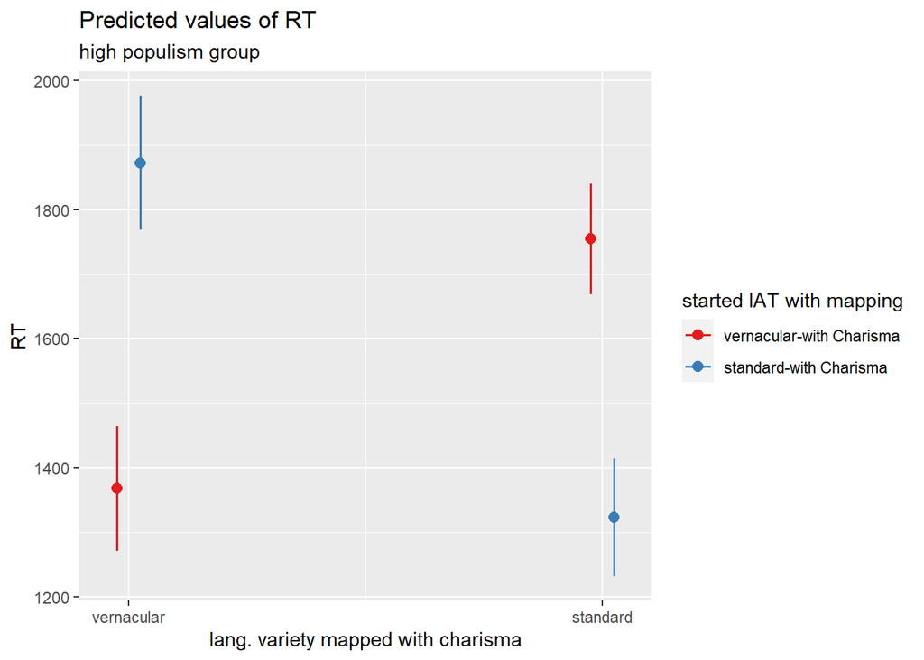

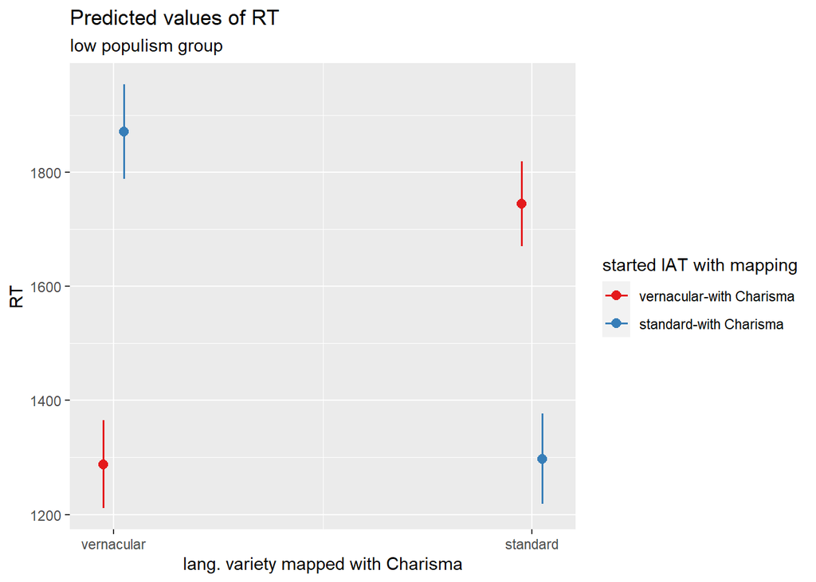

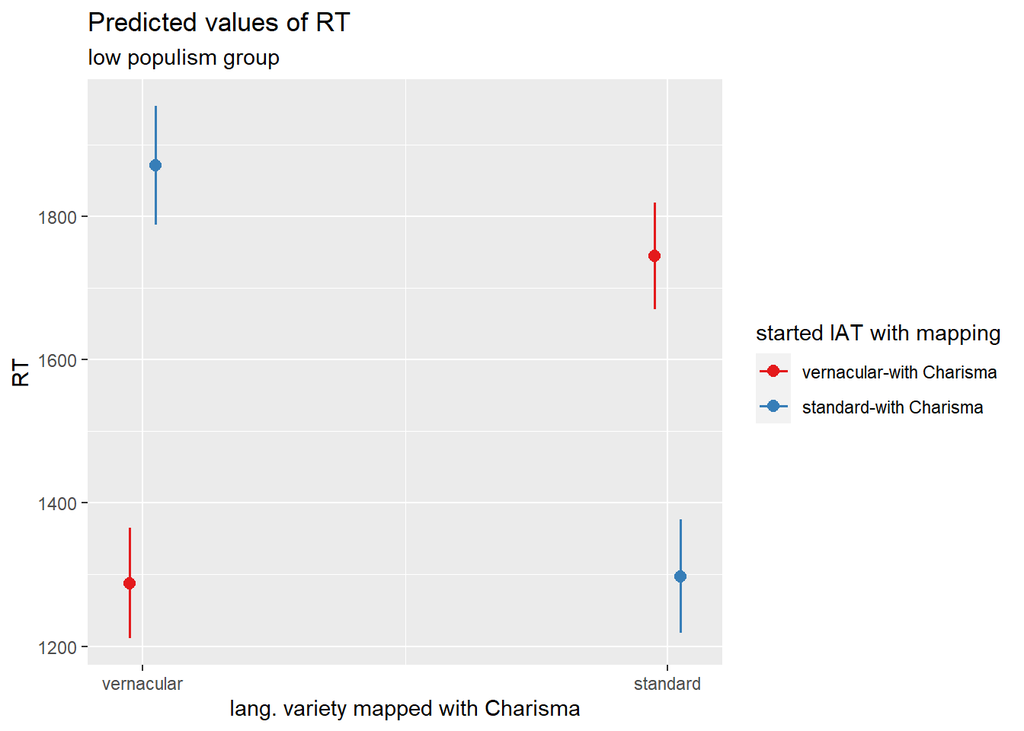

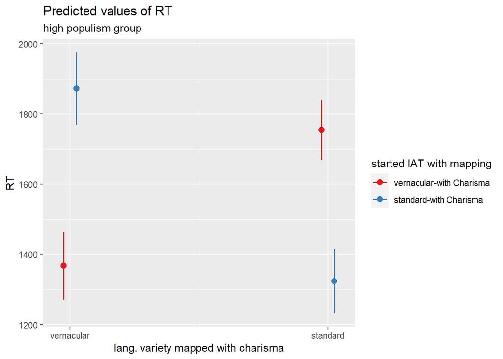

# political background measures ## populism & gender *all outgroup data* no impact of stimuli speaker/participant gender in complete data set with neither populism measure

```
## Linear mixed model fit by REML. t-tests use Satterthwaite's method [
## lmerModLmerTest]
## Formula: penal_RTs ~ charisma_lang_var * populism_all * speaker_gender +
##     start_iat + trialcount + age + +leadership_lang_var + (charisma_lang_var |
##     bilendi_id) + (start_iat | stimulus_ID)
##    Data: Four_Out
## Control: lmerControl(optimizer = "bobyqa", optCtrl = list(maxfun = 2e+05))
##
## REML criterion at convergence: 1004477
##
## Scaled residuals:
##     Min      1Q  Median      3Q     Max
## -6.3956 -0.6195 -0.1258  0.5499 13.4536
##
## Random effects:
##  Groups      Name                              Variance Std.Dev. Corr
##  bilendi_id  (Intercept)                       178461   422.45
##              charisma_lang_varvernacular       262736   512.58   -0.36
##  stimulus_ID (Intercept)                        11735   108.33
##              start_iatvernacular-with Charisma   1077    32.82   -0.05
##  Residual                                      327352   572.15
## Number of obs: 64365, groups:  bilendi_id, 537; stimulus_ID, 303
##
## Fixed effects:
##                                                              Estimate
## (Intercept)                                                 1810.6428
## charisma_lang_varvernacular                                  -38.8944
## populism_all                                                 -13.0102
## speaker_gendermale                                            75.3458
## start_iatvernacular-with Charisma                             96.3654
## trialcount                                                    -4.6233
## age                                                            4.8958
## leadership_lang_var2                                          71.0702
## charisma_lang_varvernacular:populism_all                      21.7662
## charisma_lang_varvernacular:speaker_gendermale                55.1885
## populism_all:speaker_gendermale                               -4.6612
## charisma_lang_varvernacular:populism_all:speaker_gendermale  -11.6425
##                                                             Std. Error
## (Intercept)                                                   110.2905
## charisma_lang_varvernacular                                   112.1264
```

[output cut: 49 more lines]

```
## chrsm_lng_vrvrnclr:s_  0.211 -0.673 -0.243 -0.375  0.000  0.000  0.000  0.000
## pplsm_ll:s_            0.552 -0.244 -0.677 -0.958 -0.003 -0.001 -0.017 -0.021
## chrsm__:_:_           -0.204  0.649  0.255  0.360  0.000  0.001  0.000  0.000
##                       chrsm_lng_vrvrnclr:p_ chrsm_lng_vrvrnclr:s_ ppl_:_
## chrsm_lng_v
## populism_ll
## spkr_gndrml
## strt_tvrn-C
## trialcount
## age
## ldrshp_ln_2
## chrsm_lng_vrvrnclr:p_
## chrsm_lng_vrvrnclr:s_  0.645
## pplsm_ll:s_            0.255                 0.362
## chrsm__:_:_           -0.677                -0.962                -0.376
```

```
## Type III Analysis of Variance Table with Satterthwaite's method
##                                                  Sum Sq   Mean Sq NumDF  DenDF
## charisma_lang_var                                  6030      6030     1  409.4
## populism_all                                      46083     46083     1  464.6
## speaker_gender                                   201623    201623     1  473.6
## start_iat                                       2521715   2521715     1  540.9
## trialcount                                    521664923 521664923     1 8490.2
## age                                             7147542   7147542     1  529.9
## leadership_lang_var                             1357759   1357759     1  541.6
## charisma_lang_var:populism_all                   132527    132527     1  409.4
## charisma_lang_var:speaker_gender                  35960     35960     1  409.4
## populism_all:speaker_gender                       23325     23325     1  464.5
## charisma_lang_var:populism_all:speaker_gender     17664     17664     1  409.4
##                                                 F value    Pr(>F)
## charisma_lang_var                                0.0184  0.892108
## populism_all                                     0.1408  0.707681
## speaker_gender                                   0.6159  0.432959
## start_iat                                        7.7034  0.005703 **
## trialcount                                    1593.5925 < 2.2e-16 ***
## age                                             21.8345 3.774e-06 ***
## leadership_lang_var                              4.1477  0.042177 *
## charisma_lang_var:populism_all                   0.4048  0.524952
## charisma_lang_var:speaker_gender                 0.1099  0.740482
## populism_all:speaker_gender                      0.0713  0.789639
## charisma_lang_var:populism_all:speaker_gender    0.0540  0.816426
## ---
## Signif. codes:  0 '***' 0.001 '**' 0.01 '*' 0.05 '.' 0.1 ' ' 1
```

```
## Linear mixed model fit by REML. t-tests use Satterthwaite's method [
## lmerModLmerTest]
## Formula: penal_RTs ~ charisma_lang_var * populism_dim * speaker_gender +
##     start_iat + trialcount + age + +leadership_lang_var + (charisma_lang_var |
##     bilendi_id) + (start_iat | stimulus_ID)
##    Data: Four_Out
## Control: lmerControl(optimizer = "bobyqa", optCtrl = list(maxfun = 2e+05))
##
## REML criterion at convergence: 1004480
##
## Scaled residuals:
##     Min      1Q  Median      3Q     Max
## -6.3957 -0.6195 -0.1256  0.5500 13.4541
##
## Random effects:
##  Groups      Name                              Variance Std.Dev. Corr
##  bilendi_id  (Intercept)                       177981   421.88
##              charisma_lang_varvernacular       262638   512.48   -0.36
##  stimulus_ID (Intercept)                        11735   108.33
##              start_iatvernacular-with Charisma   1077    32.82   -0.05
##  Residual                                      327352   572.15
## Number of obs: 64365, groups:  bilendi_id, 537; stimulus_ID, 303
##
## Fixed effects:
##                                                              Estimate
## (Intercept)                                                 1769.7855
## charisma_lang_varvernacular                                   30.8018
## populism_dim                                                  -6.5376
## speaker_gendermale                                            60.9198
## start_iatvernacular-with Charisma                             97.5607
## trialcount                                                    -4.6232
## age                                                            4.8616
## leadership_lang_var2                                          71.7608
## charisma_lang_varvernacular:populism_dim                      14.9580
## charisma_lang_varvernacular:speaker_gendermale                17.6768
## populism_dim:speaker_gendermale                              -15.2136
## charisma_lang_varvernacular:populism_dim:speaker_gendermale   -6.0383
##                                                             Std. Error
## (Intercept)                                                    63.5506
## charisma_lang_varvernacular                                    32.1612
```

[output cut: 49 more lines]

```
## chrsm_lng_vrvrnclr:s_  0.110 -0.711  0.009 -0.354  0.000  0.004  0.000  0.000
## pplsm_dm:s_            0.004  0.009 -0.672 -0.003 -0.012 -0.002 -0.006 -0.022
## chrsm__:_:_            0.003 -0.024  0.252  0.001 -0.001  0.006  0.000  0.000
##                       chrsm_lng_vrvrnclr:p_ chrsm_lng_vrvrnclr:s_ ppl_:_
## chrsm_lng_v
## populism_dm
## spkr_gndrml
## strt_tvrn-C
## trialcount
## age
## ldrshp_ln_2
## chrsm_lng_vrvrnclr:p_
## chrsm_lng_vrvrnclr:s_ -0.025
## pplsm_dm:s_            0.252                 0.001
## chrsm__:_:_           -0.672                -0.003                -0.375
```

```
## Type III Analysis of Variance Table with Satterthwaite's method
##                                                  Sum Sq   Mean Sq NumDF  DenDF
## charisma_lang_var                               1006633   1006633     1  410.2
## populism_dim                                     146007    146007     1  464.2
## speaker_gender                                  1119649   1119649     1  574.8
## start_iat                                       2587904   2587904     1  541.0
## trialcount                                    521653830 521653830     1 8487.2
## age                                             7044436   7044436     1  529.9
## leadership_lang_var                             1386298   1386298     1  541.6
## charisma_lang_var:populism_dim                   191610    191610     1  409.4
## charisma_lang_var:speaker_gender                  50110     50110     1  409.4
## populism_dim:speaker_gender                      182055    182055     1  463.7
## charisma_lang_var:populism_dim:speaker_gender     12253     12253     1  409.4
##                                                 F value    Pr(>F)
## charisma_lang_var                                3.0751  0.080247 .
## populism_dim                                     0.4460  0.504560
## speaker_gender                                   3.4203  0.064911 .
## start_iat                                        7.9056  0.005107 **
## trialcount                                    1593.5582 < 2.2e-16 ***
## age                                             21.5195 4.418e-06 ***
## leadership_lang_var                              4.2349  0.040079 *
## charisma_lang_var:populism_dim                   0.5853  0.444670
## charisma_lang_var:speaker_gender                 0.1531  0.695816
## populism_dim:speaker_gender                      0.5561  0.456196
## charisma_lang_var:populism_dim:speaker_gender    0.0374  0.846686
## ---
## Signif. codes:  0 '***' 0.001 '**' 0.01 '*' 0.05 '.' 0.1 ' ' 1
```

# political background measures

## populism & gender

*subset analysis* no impact of stimuli speaker/participant gender in different populism subsets (low and high populism) with neither populism measure

```
## Linear mixed model fit by REML. t-tests use Satterthwaite's method [
## lmerModLmerTest]
## Formula: penal_RTs ~ charisma_lang_var * populism_all * speaker_gender +
##     start_iat + trialcount + age + pp_gender + leadership_lang_var +
##     (charisma_lang_var | bilendi_id) + (start_iat | stimulus_ID)
##    Data: Four_Out_low_pop
## Control: lmerControl(optimizer = "bobyqa", optCtrl = list(maxfun = 2e+05))
##
## REML criterion at convergence: 469655.4
##
## Scaled residuals:
##     Min      1Q  Median      3Q     Max
## -4.9122 -0.6278 -0.1382  0.5464 12.4006
##
## Random effects:
##  Groups      Name                            Variance Std.Dev. Corr
##  stimulus_ID (Intercept)                      14030.7 118.45
##              start_iatstandard-with Charisma    904.8  30.08   -0.23
##  bilendi_id  (Intercept)                     199726.5 446.91
##              charisma_lang_varstandard       266475.6 516.21   -0.67
##  Residual                                    327689.8 572.44
## Number of obs: 30093, groups:  stimulus_ID, 303; bilendi_id, 251
##
## Fixed effects:
##                                                            Estimate Std. Error
## (Intercept)                                               1956.0416   387.3729
## charisma_lang_varstandard                                  101.7788   182.4680
## populism_all                                               -21.0015    64.8758
## speaker_gendermale                                         381.0775   240.0056
## start_iatstandard-with Charisma                              0.2241    42.8725
## trialcount                                                  -4.9734     0.1699
## age                                                          5.6921     1.2938
## pp_genderfemale                                            -61.2577   340.3045
## pp_gendermale                                             -109.2993   341.3323
## leadership_lang_var2                                        86.3108    44.0073
## charisma_lang_varstandard:populism_all                     -44.4996    74.0024
## charisma_lang_varstandard:speaker_gendermale              -143.9389   277.7270
## populism_all:speaker_gendermale                           -118.1554    95.5787
## charisma_lang_varstandard:populism_all:speaker_gendermale   43.2702   110.5486
##                                                                  df t value
```

[output cut: 16 more lines]

```
## charisma_lang_varstandard                                    0.578
## populism_all                                                 0.747
## speaker_gendermale                                           0.115
## start_iatstandard-with Charisma                              0.996
## trialcount                                                 < 2e-16 ***
## age                                                       1.63e-05 ***
## pp_genderfemale                                              0.857
## pp_gendermale                                                0.749
## leadership_lang_var2                                         0.051 .
## charisma_lang_varstandard:populism_all                       0.548
## charisma_lang_varstandard:speaker_gendermale                 0.605
## populism_all:speaker_gendermale                              0.219
## charisma_lang_varstandard:populism_all:speaker_gendermale    0.696
## ---
## Signif. codes:  0 '***' 0.001 '**' 0.01 '*' 0.05 '.' 0.1 ' ' 1
```

```
##
## Correlation matrix not shown by default, as p = 14 > 12.
## Use print(x, correlation=TRUE)  or
##     vcov(x)        if you need it
```

```
## Type III Analysis of Variance Table with Satterthwaite's method
##                                                  Sum Sq   Mean Sq NumDF  DenDF
## charisma_lang_var                                 15109     15109     1  184.3
## populism_all                                    2017690   2017690     1  233.1
## speaker_gender                                   967122    967122     1  234.2
## start_iat                                             9         9     1  243.6
## trialcount                                    280704212 280704212     1 3919.4
## age                                             6343003   6343003     1  242.1
## pp_gender                                        398680    199340     2  242.0
## leadership_lang_var                             1260505   1260505     1  247.7
## charisma_lang_var:populism_all                    56105     56105     1  184.3
## charisma_lang_var:speaker_gender                  88020     88020     1  184.5
## populism_all:speaker_gender                      594167    594167     1  231.6
## charisma_lang_var:populism_all:speaker_gender     50203     50203     1  184.5
##                                                F value    Pr(>F)
## charisma_lang_var                               0.0461   0.83022
## populism_all                                    6.1573   0.01379 *
## speaker_gender                                  2.9513   0.08713 .
## start_iat                                       0.0000   0.99583
## trialcount                                    856.6156 < 2.2e-16 ***
## age                                            19.3567 1.626e-05 ***
## pp_gender                                       0.6083   0.54509
## leadership_lang_var                             3.8466   0.05097 .
## charisma_lang_var:populism_all                  0.1712   0.67952
## charisma_lang_var:speaker_gender                0.2686   0.60489
## populism_all:speaker_gender                     1.8132   0.17944
## charisma_lang_var:populism_all:speaker_gender   0.1532   0.69594
## ---
## Signif. codes:  0 '***' 0.001 '**' 0.01 '*' 0.05 '.' 0.1 ' ' 1
```

```
## Linear mixed model fit by REML. t-tests use Satterthwaite's method [
## lmerModLmerTest]
## Formula: penal_RTs ~ charisma_lang_var * populism_all * speaker_gender +
##     start_iat + trialcount + age + pp_gender + leadership_lang_var +
##     (charisma_lang_var | bilendi_id) + (start_iat | stimulus_ID)
##    Data: Four_Out_high_pop
## Control: lmerControl(optimizer = "bobyqa", optCtrl = list(maxfun = 2e+05))
##
## REML criterion at convergence: 534889.6
##
## Scaled residuals:
##     Min      1Q  Median      3Q     Max
## -6.4418 -0.6102 -0.1166  0.5583 13.4815
##
## Random effects:
##  Groups      Name                            Variance Std.Dev. Corr
##  stimulus_ID (Intercept)                      13411   115.80
##              start_iatstandard-with Charisma   2498    49.98   -0.39
##  bilendi_id  (Intercept)                     358837   599.03
##              charisma_lang_varstandard       264805   514.59   -0.68
##  Residual                                    326275   571.21
## Number of obs: 34272, groups:  stimulus_ID, 303; bilendi_id, 286
##
## Fixed effects:
##                                                            Estimate Std. Error
## (Intercept)                                               2123.0999   393.0638
## charisma_lang_varstandard                                 -199.9057   334.2397
## populism_all                                               -36.3654    98.4364
## speaker_gendermale                                        -306.1345   555.7943
## start_iatstandard-with Charisma                           -172.0762    53.3292
## trialcount                                                  -4.3308     0.1588
## age                                                          3.8519     1.6534
## pp_gendermale                                              -16.6692    53.1787
## leadership_lang_var2                                        38.7390    53.3229
## charisma_lang_varstandard:populism_all                      37.4481    85.2834
## charisma_lang_varstandard:speaker_gendermale               331.7658   480.7191
## populism_all:speaker_gendermale                             98.7633   142.4090
## charisma_lang_varstandard:populism_all:speaker_gendermale  -85.1326   123.3435
##                                                                  df t value
## (Intercept)                                                188.7165   5.401
```

[output cut: 13 more lines]

```
## (Intercept)                                               1.97e-07 ***
## charisma_lang_varstandard                                   0.5504
## populism_all                                                0.7122
## speaker_gendermale                                          0.5824
## start_iatstandard-with Charisma                             0.0014 **
## trialcount                                                 < 2e-16 ***
## age                                                         0.0205 *
## pp_gendermale                                               0.7542
## leadership_lang_var2                                        0.4681
## charisma_lang_varstandard:populism_all                      0.6610
## charisma_lang_varstandard:speaker_gendermale                0.4908
## populism_all:speaker_gendermale                             0.4889
## charisma_lang_varstandard:populism_all:speaker_gendermale   0.4908
## ---
## Signif. codes:  0 '***' 0.001 '**' 0.01 '*' 0.05 '.' 0.1 ' ' 1
```

```
##
## Correlation matrix not shown by default, as p = 13 > 12.
## Use print(x, correlation=TRUE)  or
##     vcov(x)        if you need it
```

```
## Type III Analysis of Variance Table with Satterthwaite's method
##                                                  Sum Sq   Mean Sq NumDF  DenDF
## charisma_lang_var                                  6539      6539     1  222.8
## populism_all                                      11327     11327     1  239.7
## speaker_gender                                    34487     34487     1  237.0
## start_iat                                       3396996   3396996     1  287.5
## trialcount                                    242647581 242647581     1 4659.7
## age                                             1770831   1770831     1  278.0
## pp_gender                                         32058     32058     1  278.0
## leadership_lang_var                              172208    172208     1  281.9
## charisma_lang_var:populism_all                     2248      2248     1  222.8
## charisma_lang_var:speaker_gender                 155405    155405     1  222.9
## populism_all:speaker_gender                       84491     84491     1  236.2
## charisma_lang_var:populism_all:speaker_gender    155433    155433     1  222.9
##                                                F value    Pr(>F)
## charisma_lang_var                               0.0200  0.887550
## populism_all                                    0.0347  0.852352
## speaker_gender                                  0.1057  0.745383
## start_iat                                      10.4114  0.001397 **
## trialcount                                    743.6899 < 2.2e-16 ***
## age                                             5.4274  0.020539 *
## pp_gender                                       0.0983  0.754169
## leadership_lang_var                             0.5278  0.468136
## charisma_lang_var:populism_all                  0.0069  0.933925
## charisma_lang_var:speaker_gender                0.4763  0.490821
## populism_all:speaker_gender                     0.2590  0.611314
## charisma_lang_var:populism_all:speaker_gender   0.4764  0.490782
## ---
## Signif. codes:  0 '***' 0.001 '**' 0.01 '*' 0.05 '.' 0.1 ' ' 1
```

## political background measures

### political ideology

```
## Linear mixed model fit by REML. t-tests use Satterthwaite's method [
## lmerModLmerTest]
## Formula: penal_RTs ~ charisma_lang_var * start_iat * ideology + trialcount +
##     age + leadership_lang_var + (charisma_lang_var | bilendi_id) +
##     (start_iat | stimulus_ID)
##    Data: Four_Out
## Control: lmerControl(optimizer = "bobyqa", optCtrl = list(maxfun = 2e+05))
##
## REML criterion at convergence: 1003967
##
## Scaled residuals:
##     Min      1Q  Median      3Q     Max
## -6.2927 -0.6203 -0.1218  0.5497 13.5404
##
## Random effects:
##  Groups      Name                              Variance Std.Dev. Corr
##  bilendi_id  (Intercept)                       163947   404.90
##              charisma_lang_varvernacular       109368   330.71   -0.25
##  stimulus_ID (Intercept)                        11740   108.35
##              start_iatvernacular-with Charisma   1066    32.66   -0.05
##  Residual                                      326949   571.79
## Number of obs: 64365, groups:  bilendi_id, 537; stimulus_ID, 303
##
## Fixed effects:
##                                                                          Estimate
## (Intercept)                                                             1762.3743
## charisma_lang_varvernacular                                              562.0973
## start_iatvernacular-with Charisma                                        437.9987
## ideology                                                                 -41.0263
## trialcount                                                                -5.7766
## age                                                                        4.7299
## leadership_lang_var2                                                      66.3164
## charisma_lang_varvernacular:start_iatvernacular-with Charisma           -981.2823
## charisma_lang_varvernacular:ideology                                     -96.3824
## start_iatvernacular-with Charisma:ideology                                26.8126
## charisma_lang_varvernacular:start_iatvernacular-with Charisma:ideology   123.6020
##                                                                        Std. Error
## (Intercept)                                                               58.5161
## charisma_lang_varvernacular                                               24.9998
## start_iatvernacular-with Charisma                                         37.6028
```

[output cut: 67 more lines]

```
## chrsm__:_-C -0.025 -0.800 -0.399 -0.003  0.616  0.000  0.000
## chrsm_lng_:  0.002 -0.015 -0.003 -0.276  0.000  0.000  0.000  0.010
## strt_tvr-C:  0.042 -0.003 -0.005 -0.775  0.000 -0.039 -0.015  0.001    0.214
## chrs__:_-C: -0.002  0.011  0.001  0.214  0.000  0.000  0.000 -0.003   -0.775
##             st_-C:
## chrsm_lng_v
## strt_tvrn-C
## ideology
## trialcount
## age
## ldrshp_ln_2
## chrsm__:_-C
## chrsm_lng_:
## strt_tvr-C:
## chrs__:_-C: -0.276
```

```
## Type III Analysis of Variance Table with Satterthwaite's method
##                                         Sum Sq   Mean Sq NumDF DenDF   F value
## charisma_lang_var                      7400461   7400461     1   533   22.6349
## start_iat                               751416    751416     1   533    2.2983
## ideology                               2119537   2119537     1   530    6.4828
## trialcount                           641950126 641950126     1 63022 1963.4544
## age                                    6763812   6763812     1   531   20.6876
## leadership_lang_var                    1190248   1190248     1   542    3.6405
## charisma_lang_var:start_iat          216682703 216682703     1  1376  662.7409
## charisma_lang_var:ideology             1673663   1673663     1   533    5.1190
## start_iat:ideology                     2062195   2062195     1   530    6.3074
## charisma_lang_var:start_iat:ideology   5345408   5345408     1   533   16.3493
##                                         Pr(>F)
## charisma_lang_var                    2.526e-06 ***
## start_iat                              0.13011
## ideology                               0.01117 *
## trialcount                           < 2.2e-16 ***
## age                                  6.704e-06 ***
## leadership_lang_var                    0.05692 .
## charisma_lang_var:start_iat          < 2.2e-16 ***
## charisma_lang_var:ideology             0.02407 *
## start_iat:ideology                     0.01232 *
## charisma_lang_var:start_iat:ideology 6.046e-05 ***
## ---
## Signif. codes:  0 '***' 0.001 '**' 0.01 '*' 0.05 '.' 0.1 ' ' 1
```

```
## Note: D.f. calculations have been disabled because the number of observations exceeds 3000.
## To enable adjustments, add the argument 'pbkrtest.limit = 64365' (or larger)
## [or, globally, 'set emm_options(pbkrtest.limit = 64365)' or larger];
## but be warned that this may result in large computation time and memory use.
```

```
## Note: D.f. calculations have been disabled because the number of observations exceeds 3000.
## To enable adjustments, add the argument 'lmerTest.limit = 64365' (or larger)
## [or, globally, 'set emm_options(lmerTest.limit = 64365)' or larger];
## but be warned that this may result in large computation time and memory use.
```

```
## start_iat = standard-with Charisma:
##  charisma_lang_var ideology.trend   SE  df asymp.LCL asymp.UCL
##  standard                   -41.0 28.1 Inf     -96.2      14.1
##  vernacular                -137.4 31.4 Inf    -198.9     -75.9
##
## start_iat = vernacular-with Charisma:
##  charisma_lang_var ideology.trend   SE  df asymp.LCL asymp.UCL
##  standard                   -14.2 22.9 Inf     -59.2      30.7
##  vernacular                  13.0 25.6 Inf     -37.1      63.1
##
## Results are averaged over the levels of: leadership_lang_var
## Degrees-of-freedom method: asymptotic
## Confidence level used: 0.95
```

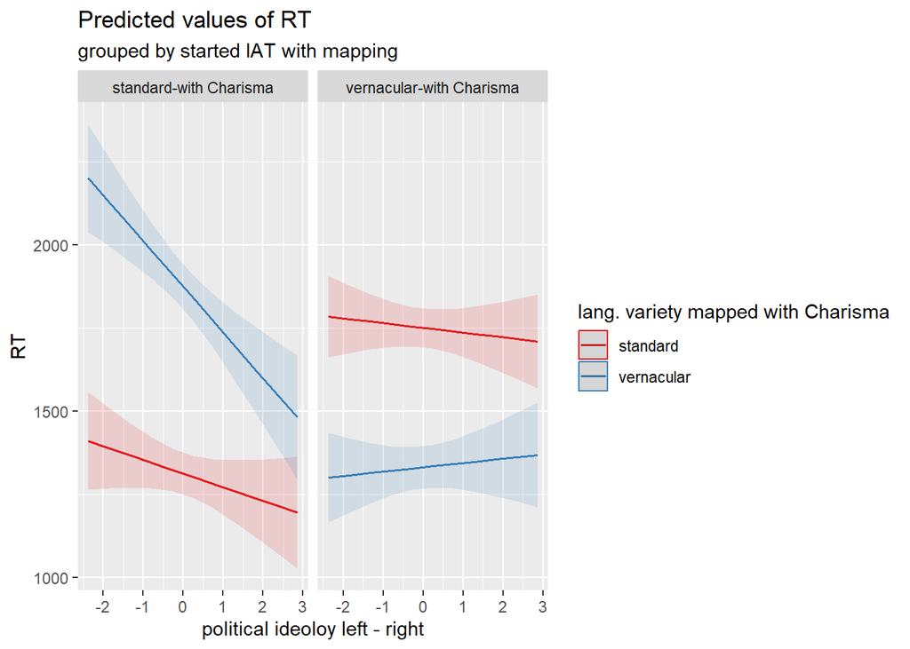

## political background measures ### political ideology & gender

```
## Linear mixed model fit by REML. t-tests use Satterthwaite's method [
## lmerModLmerTest]
## Formula:
## penal_RTs ~ charisma_lang_var * ideology * speaker_gender + start_iat +
##     trialcount + age + pp_gender + leadership_lang_var + (charisma_lang_var |
##     bilendi_id) + (start_iat | stimulus_ID)
##    Data: Four_Out
## Control: lmerControl(optimizer = "bobyqa", optCtrl = list(maxfun = 2e+05))
##
## REML criterion at convergence: 1004452
##
## Scaled residuals:
##     Min      1Q  Median      3Q     Max
## -6.3980 -0.6193 -0.1257  0.5502 13.4532
##
## Random effects:
##  Groups      Name                              Variance Std.Dev. Corr
##  bilendi_id  (Intercept)                       179125   423.23
##              charisma_lang_varvernacular       262424   512.27   -0.37
##  stimulus_ID (Intercept)                        11735   108.33
##              start_iatvernacular-with Charisma   1076    32.81   -0.05
##  Residual                                      327353   572.15
## Number of obs: 64365, groups:  bilendi_id, 537; stimulus_ID, 303
##
## Fixed effects:
##                                                          Estimate Std. Error
## (Intercept)                                             1780.3669   403.1669
## charisma_lang_varvernacular                               30.1163    32.1567
## ideology                                                 -37.2447    28.5723
## speaker_gendermale                                        57.7570    39.4438
## start_iatvernacular-with Charisma                         91.2384    34.7437
## trialcount                                                -4.6210     0.1158
## age                                                        4.9361     1.0472
## pp_genderfemale                                           -6.5020   400.1924
## pp_gendermale                                             -9.1244   400.6738
## leadership_lang_var2                                      68.0798    34.9215
## charisma_lang_varvernacular:ideology                      -2.8377    34.4024
## charisma_lang_varvernacular:speaker_gendermale            17.8385    45.1665
## ideology:speaker_gendermale                               20.7053    37.6119
## charisma_lang_varvernacular:ideology:speaker_gendermale  -23.5437    45.6042
```

[output cut: 17 more lines]

```
## charisma_lang_varvernacular                              0.34954
## ideology                                                 0.19313
## speaker_gendermale                                       0.14375
## start_iatvernacular-with Charisma                        0.00888 **
## trialcount                                               < 2e-16 ***
## age                                                     3.12e-06 ***
## pp_genderfemale                                          0.98704
## pp_gendermale                                            0.98184
## leadership_lang_var2                                     0.05175 .
## charisma_lang_varvernacular:ideology                     0.93430
## charisma_lang_varvernacular:speaker_gendermale           0.69309
## ideology:speaker_gendermale                              0.58228
## charisma_lang_varvernacular:ideology:speaker_gendermale  0.60595
## ---
## Signif. codes:  0 '***' 0.001 '**' 0.01 '*' 0.05 '.' 0.1 ' ' 1
```

```
##
## Correlation matrix not shown by default, as p = 14 > 12.
## Use print(x, correlation=TRUE)  or
##     vcov(x)        if you need it
```

```
## Type III Analysis of Variance Table with Satterthwaite's method
##                                              Sum Sq   Mean Sq NumDF  DenDF
## charisma_lang_var                            976776    976776     1  409.7
## ideology                                    1171586   1171586     1  469.9
## speaker_gender                              1021839   1021839     1  578.0
## start_iat                                   2257458   2257458     1  538.4
## trialcount                                521176090 521176090     1 8477.4
## age                                         7273257   7273257     1  527.9
## pp_gender                                      1958       979     2  527.9
## leadership_lang_var                         1244133   1244133     1  539.6
## charisma_lang_var:ideology                   134396    134396     1  408.9
## charisma_lang_var:speaker_gender              51063     51063     1  408.9
## ideology:speaker_gender                       20403     20403     1  466.8
## charisma_lang_var:ideology:speaker_gender     87248     87248     1  409.0
##                                             F value    Pr(>F)
## charisma_lang_var                            2.9839  0.084852 .
## ideology                                     3.5790  0.059130 .
## speaker_gender                               3.1215  0.077793 .
## start_iat                                    6.8961  0.008884 **
## trialcount                                1592.0906 < 2.2e-16 ***
## age                                         22.2184 3.117e-06 ***
## pp_gender                                    0.0030  0.997014
## leadership_lang_var                          3.8006  0.051752 .
## charisma_lang_var:ideology                   0.4106  0.522047
## charisma_lang_var:speaker_gender             0.1560  0.693085
## ideology:speaker_gender                      0.0623  0.802967
## charisma_lang_var:ideology:speaker_gender    0.2665  0.605951
## ---
## Signif. codes:  0 '***' 0.001 '**' 0.01 '*' 0.05 '.' 0.1 ' ' 1
```

# political background measures

## voting behaviour

Simple effects in contrasts lang. variety level vernacular and Grün vs. LINKE, CDU/CSU vs. LINKE, AfD vs.LINKe approaching significance

```
## Linear mixed model fit by REML. t-tests use Satterthwaite's method [
## lmerModLmerTest]
## Formula: penal_RTs ~ charisma_lang_var * start_iat * voting_behaviour +
##     trialcount + age + leadership_lang_var + (charisma_lang_var |
##     bilendi_id) + (start_iat | stimulus_ID)
##    Data: Four_Out
## Control: lmerControl(optimizer = "bobyqa", optCtrl = list(maxfun = 2e+05))
##
## REML criterion at convergence: 1003593
##
## Scaled residuals:
##     Min      1Q  Median      3Q     Max
## -6.2849 -0.6198 -0.1215  0.5499 13.5396
##
## Random effects:
##  Groups      Name                              Variance Std.Dev. Corr
##  bilendi_id  (Intercept)                       164970   406.16
##              charisma_lang_varvernacular       112062   334.76   -0.25
##  stimulus_ID (Intercept)                        11728   108.30
##              start_iatvernacular-with Charisma   1063    32.61   -0.05
##  Residual                                      326950   571.80
## Number of obs: 64365, groups:  bilendi_id, 537; stimulus_ID, 303
##
## Fixed effects:
##                                                                                             Estimate
## (Intercept)                                                                                1702.3042
## charisma_lang_varvernacular                                                                 514.9922
## start_iatvernacular-with Charisma                                                           532.5818
## voting_behaviourandere                                                                      -50.2317
## voting_behaviourCDU/CSU                                                                      40.4447
## voting_behaviourDIE LINKE                                                                   -16.7092
## voting_behaviourFDP                                                                         -29.5236
## voting_behaviourGRüNE                                                                       155.7652
## voting_behaviourinvalid                                                                      35.9412
## voting_behaviourNichtwähler                                                                  51.0425
## voting_behaviourno_answer                                                                   111.8960
## voting_behaviourSPD                                                                         150.1658
## trialcount                                                                                   -5.7766
## age                                                                                           4.6777
## leadership_lang_var2                                                                         64.4529
```

[output cut: 235 more lines]

```
## start_iatvernacular-with Charisma:voting_behaviourinvalid
## start_iatvernacular-with Charisma:voting_behaviourNichtwähler
## start_iatvernacular-with Charisma:voting_behaviourno_answer
## start_iatvernacular-with Charisma:voting_behaviourSPD
## charisma_lang_varvernacular:start_iatvernacular-with Charisma:voting_behaviourandere
## charisma_lang_varvernacular:start_iatvernacular-with Charisma:voting_behaviourCDU/CSU
## charisma_lang_varvernacular:start_iatvernacular-with Charisma:voting_behaviourDIE LINKE   .
## charisma_lang_varvernacular:start_iatvernacular-with Charisma:voting_behaviourFDP
## charisma_lang_varvernacular:start_iatvernacular-with Charisma:voting_behaviourGRüNE
## charisma_lang_varvernacular:start_iatvernacular-with Charisma:voting_behaviourinvalid
## charisma_lang_varvernacular:start_iatvernacular-with Charisma:voting_behaviourNichtwähler
## charisma_lang_varvernacular:start_iatvernacular-with Charisma:voting_behaviourno_answer
## charisma_lang_varvernacular:start_iatvernacular-with Charisma:voting_behaviourSPD
## ---
## Signif. codes:  0 '***' 0.001 '**' 0.01 '*' 0.05 '.' 0.1 ' ' 1
```

```
##
## Correlation matrix not shown by default, as p = 43 > 12.
## Use print(x, correlation=TRUE)  or
##     vcov(x)        if you need it
```

```
## Linear mixed model fit by REML. t-tests use Satterthwaite's method [
## lmerModLmerTest]
## Formula: penal_RTs ~ charisma_lang_var * voting_behaviour * start_iat +
##     trialcount + age + leadership_lang_var + (charisma_lang_var |
##     bilendi_id) + (start_iat | stimulus_ID)
##    Data: Four_Out
## Control: lmerControl(optimizer = "bobyqa", optCtrl = list(maxfun = 2e+05))
##
## REML criterion at convergence: 1003593
##
## Scaled residuals:
##     Min      1Q  Median      3Q     Max
## -6.2849 -0.6198 -0.1215  0.5499 13.5396
##
## Random effects:
##  Groups      Name                              Variance Std.Dev. Corr
##  bilendi_id  (Intercept)                       164969   406.16
##              charisma_lang_varvernacular       112061   334.76   -0.25
##  stimulus_ID (Intercept)                        11728   108.30
##              start_iatvernacular-with Charisma   1063    32.61   -0.05
##  Residual                                      326950   571.80
## Number of obs: 64365, groups:  bilendi_id, 537; stimulus_ID, 303
##
## Fixed effects:
##                                                                                             Estimate
## (Intercept)                                                                                1672.7808
## charisma_lang_varvernacular                                                                 456.2769
## voting_behaviourAfD                                                                          29.5238
## voting_behaviourandere                                                                      -20.7078
## voting_behaviourCDU/CSU                                                                      69.9686
## voting_behaviourDIE LINKE                                                                    12.8147
## voting_behaviourGRüNE                                                                       185.2890
## voting_behaviourinvalid                                                                      65.4649
## voting_behaviourNichtwähler                                                                  80.5663
## voting_behaviourno_answer                                                                   141.4198
## voting_behaviourSPD                                                                         179.6896
## start_iatvernacular-with Charisma                                                           456.2581
## trialcount                                                                                   -5.7766
## age                                                                                           4.6777
## leadership_lang_var2                                                                         64.4531
```

[output cut: 235 more lines]

```
## voting_behaviourinvalid:start_iatvernacular-with Charisma
## voting_behaviourNichtwähler:start_iatvernacular-with Charisma
## voting_behaviourno_answer:start_iatvernacular-with Charisma
## voting_behaviourSPD:start_iatvernacular-with Charisma
## charisma_lang_varvernacular:voting_behaviourAfD:start_iatvernacular-with Charisma
## charisma_lang_varvernacular:voting_behaviourandere:start_iatvernacular-with Charisma
## charisma_lang_varvernacular:voting_behaviourCDU/CSU:start_iatvernacular-with Charisma
## charisma_lang_varvernacular:voting_behaviourDIE LINKE:start_iatvernacular-with Charisma
## charisma_lang_varvernacular:voting_behaviourGRüNE:start_iatvernacular-with Charisma
## charisma_lang_varvernacular:voting_behaviourinvalid:start_iatvernacular-with Charisma
## charisma_lang_varvernacular:voting_behaviourNichtwähler:start_iatvernacular-with Charisma
## charisma_lang_varvernacular:voting_behaviourno_answer:start_iatvernacular-with Charisma
## charisma_lang_varvernacular:voting_behaviourSPD:start_iatvernacular-with Charisma
## ---
## Signif. codes:  0 '***' 0.001 '**' 0.01 '*' 0.05 '.' 0.1 ' ' 1
```

```
##
## Correlation matrix not shown by default, as p = 43 > 12.
## Use print(x, correlation=TRUE)  or
##     vcov(x)        if you need it
```

```
## Linear mixed model fit by REML. t-tests use Satterthwaite's method [
## lmerModLmerTest]
## Formula: penal_RTs ~ charisma_lang_var * voting_behaviour * start_iat +
##     trialcount + age + leadership_lang_var + (charisma_lang_var |
##     bilendi_id) + (start_iat | stimulus_ID)
##    Data: Four_Out
## Control: lmerControl(optimizer = "bobyqa", optCtrl = list(maxfun = 2e+05))
##
## REML criterion at convergence: 1003593
##
## Scaled residuals:
##     Min      1Q  Median      3Q     Max
## -6.2849 -0.6198 -0.1215  0.5499 13.5396
##
## Random effects:
##  Groups      Name                              Variance Std.Dev. Corr
##  bilendi_id  (Intercept)                       164969   406.16
##              charisma_lang_varvernacular       112062   334.76   -0.25
##  stimulus_ID (Intercept)                        11728   108.30
##              start_iatvernacular-with Charisma   1063    32.61   -0.05
##  Residual                                      326950   571.80
## Number of obs: 64365, groups:  bilendi_id, 537; stimulus_ID, 303
##
## Fixed effects:
##                                                                                             Estimate
## (Intercept)                                                                                1858.0696
## charisma_lang_varvernacular                                                                 530.1243
## voting_behaviourFDP                                                                        -185.2889
## voting_behaviourAfD                                                                        -155.7652
## voting_behaviourandere                                                                     -205.9969
## voting_behaviourCDU/CSU                                                                    -115.3205
## voting_behaviourDIE LINKE                                                                  -172.4744
## voting_behaviourinvalid                                                                    -119.8240
## voting_behaviourNichtwähler                                                                -104.7227
## voting_behaviourno_answer                                                                   -43.8692
## voting_behaviourSPD                                                                          -5.5994
## start_iatvernacular-with Charisma                                                           408.8388
## trialcount                                                                                   -5.7766
## age                                                                                           4.6777
## leadership_lang_var2                                                                         64.4530
```

[output cut: 235 more lines]

```
## voting_behaviourinvalid:start_iatvernacular-with Charisma
## voting_behaviourNichtwähler:start_iatvernacular-with Charisma
## voting_behaviourno_answer:start_iatvernacular-with Charisma
## voting_behaviourSPD:start_iatvernacular-with Charisma
## charisma_lang_varvernacular:voting_behaviourFDP:start_iatvernacular-with Charisma
## charisma_lang_varvernacular:voting_behaviourAfD:start_iatvernacular-with Charisma
## charisma_lang_varvernacular:voting_behaviourandere:start_iatvernacular-with Charisma
## charisma_lang_varvernacular:voting_behaviourCDU/CSU:start_iatvernacular-with Charisma
## charisma_lang_varvernacular:voting_behaviourDIE LINKE:start_iatvernacular-with Charisma   *
## charisma_lang_varvernacular:voting_behaviourinvalid:start_iatvernacular-with Charisma
## charisma_lang_varvernacular:voting_behaviourNichtwähler:start_iatvernacular-with Charisma
## charisma_lang_varvernacular:voting_behaviourno_answer:start_iatvernacular-with Charisma   .
## charisma_lang_varvernacular:voting_behaviourSPD:start_iatvernacular-with Charisma
## ---
## Signif. codes:  0 '***' 0.001 '**' 0.01 '*' 0.05 '.' 0.1 ' ' 1
```

```
##
## Correlation matrix not shown by default, as p = 43 > 12.
## Use print(x, correlation=TRUE)  or
##     vcov(x)        if you need it
```

```
## Linear mixed model fit by REML. t-tests use Satterthwaite's method [
## lmerModLmerTest]
## Formula: penal_RTs ~ charisma_lang_var * voting_behaviour * start_iat +
##     trialcount + age + leadership_lang_var + (charisma_lang_var |
##     bilendi_id) + (start_iat | stimulus_ID)
##    Data: Four_Out
## Control: lmerControl(optimizer = "bobyqa", optCtrl = list(maxfun = 2e+05))
##
## REML criterion at convergence: 1003593
##
## Scaled residuals:
##     Min      1Q  Median      3Q     Max
## -6.2849 -0.6198 -0.1215  0.5499 13.5396
##
## Random effects:
##  Groups      Name                              Variance Std.Dev. Corr
##  bilendi_id  (Intercept)                       164969   406.16
##              charisma_lang_varvernacular       112061   334.76   -0.25
##  stimulus_ID (Intercept)                        11728   108.30
##              start_iatvernacular-with Charisma   1063    32.61   -0.05
##  Residual                                      326950   571.80
## Number of obs: 64365, groups:  bilendi_id, 537; stimulus_ID, 303
##
## Fixed effects:
##                                                                                             Estimate
## (Intercept)                                                                                1742.7489
## charisma_lang_varvernacular                                                                 488.6001
## voting_behaviourGRüNE                                                                       115.3206
## voting_behaviourFDP                                                                         -69.9683
## voting_behaviourAfD                                                                         -40.4447
## voting_behaviourandere                                                                      -90.6763
## voting_behaviourDIE LINKE                                                                   -57.1538
## voting_behaviourinvalid                                                                      -4.5035
## voting_behaviourNichtwähler                                                                  10.5978
## voting_behaviourno_answer                                                                    71.4513
## voting_behaviourSPD                                                                         109.7211
## start_iatvernacular-with Charisma                                                           378.8279
## trialcount                                                                                   -5.7766
## age                                                                                           4.6777
## leadership_lang_var2                                                                         64.4529
```

[output cut: 235 more lines]

```
## voting_behaviourinvalid:start_iatvernacular-with Charisma
## voting_behaviourNichtwähler:start_iatvernacular-with Charisma
## voting_behaviourno_answer:start_iatvernacular-with Charisma
## voting_behaviourSPD:start_iatvernacular-with Charisma
## charisma_lang_varvernacular:voting_behaviourGRüNE:start_iatvernacular-with Charisma
## charisma_lang_varvernacular:voting_behaviourFDP:start_iatvernacular-with Charisma
## charisma_lang_varvernacular:voting_behaviourAfD:start_iatvernacular-with Charisma
## charisma_lang_varvernacular:voting_behaviourandere:start_iatvernacular-with Charisma
## charisma_lang_varvernacular:voting_behaviourDIE LINKE:start_iatvernacular-with Charisma   *
## charisma_lang_varvernacular:voting_behaviourinvalid:start_iatvernacular-with Charisma
## charisma_lang_varvernacular:voting_behaviourNichtwähler:start_iatvernacular-with Charisma
## charisma_lang_varvernacular:voting_behaviourno_answer:start_iatvernacular-with Charisma   .
## charisma_lang_varvernacular:voting_behaviourSPD:start_iatvernacular-with Charisma
## ---
## Signif. codes:  0 '***' 0.001 '**' 0.01 '*' 0.05 '.' 0.1 ' ' 1
```

```
##
## Correlation matrix not shown by default, as p = 43 > 12.
## Use print(x, correlation=TRUE)  or
##     vcov(x)        if you need it
```

```
## Linear mixed model fit by REML. t-tests use Satterthwaite's method [
## lmerModLmerTest]
## Formula: penal_RTs ~ charisma_lang_var * voting_behaviour * start_iat +
##     trialcount + age + leadership_lang_var + (charisma_lang_var |
##     bilendi_id) + (start_iat | stimulus_ID)
##    Data: Four_Out
## Control: lmerControl(optimizer = "bobyqa", optCtrl = list(maxfun = 2e+05))
##
## REML criterion at convergence: 1003593
##
## Scaled residuals:
##     Min      1Q  Median      3Q     Max
## -6.2849 -0.6198 -0.1215  0.5499 13.5396
##
## Random effects:
##  Groups      Name                              Variance Std.Dev. Corr
##  bilendi_id  (Intercept)                       164969   406.16
##              charisma_lang_varvernacular       112062   334.76   -0.25
##  stimulus_ID (Intercept)                        11728   108.30
##              start_iatvernacular-with Charisma   1063    32.61   -0.05
##  Residual                                      326950   571.80
## Number of obs: 64365, groups:  bilendi_id, 537; stimulus_ID, 303
##
## Fixed effects:
##                                                                                             Estimate
## (Intercept)                                                                                1685.5951
## charisma_lang_varvernacular                                                                 808.5989
## voting_behaviourCDU/CSU                                                                      57.1538
## voting_behaviourGRüNE                                                                       172.4744
## voting_behaviourFDP                                                                         -12.8145
## voting_behaviourAfD                                                                          16.7092
## voting_behaviourandere                                                                      -33.5225
## voting_behaviourinvalid                                                                      52.6504
## voting_behaviourNichtwähler                                                                  67.7517
## voting_behaviourno_answer                                                                   128.6052
## voting_behaviourSPD                                                                         166.8750
## start_iatvernacular-with Charisma                                                           459.4897
## trialcount                                                                                   -5.7766
## age                                                                                           4.6777
## leadership_lang_var2                                                                         64.4529
```

[output cut: 235 more lines]

```
## voting_behaviourinvalid:start_iatvernacular-with Charisma
## voting_behaviourNichtwähler:start_iatvernacular-with Charisma
## voting_behaviourno_answer:start_iatvernacular-with Charisma
## voting_behaviourSPD:start_iatvernacular-with Charisma
## charisma_lang_varvernacular:voting_behaviourCDU/CSU:start_iatvernacular-with Charisma     *
## charisma_lang_varvernacular:voting_behaviourGRüNE:start_iatvernacular-with Charisma       *
## charisma_lang_varvernacular:voting_behaviourFDP:start_iatvernacular-with Charisma
## charisma_lang_varvernacular:voting_behaviourAfD:start_iatvernacular-with Charisma         .
## charisma_lang_varvernacular:voting_behaviourandere:start_iatvernacular-with Charisma
## charisma_lang_varvernacular:voting_behaviourinvalid:start_iatvernacular-with Charisma     **
## charisma_lang_varvernacular:voting_behaviourNichtwähler:start_iatvernacular-with Charisma .
## charisma_lang_varvernacular:voting_behaviourno_answer:start_iatvernacular-with Charisma
## charisma_lang_varvernacular:voting_behaviourSPD:start_iatvernacular-with Charisma
## ---
## Signif. codes:  0 '***' 0.001 '**' 0.01 '*' 0.05 '.' 0.1 ' ' 1
```

```
##
## Correlation matrix not shown by default, as p = 43 > 12.
## Use print(x, correlation=TRUE)  or
##     vcov(x)        if you need it
```

```
## Type III Analysis of Variance Table with Satterthwaite's method
##                                                 Sum Sq   Mean Sq NumDF DenDF
## charisma_lang_var                              6337978   6337978     1   517
## voting_behaviour                               4727884    525320     9   514
## start_iat                                        39357     39357     1   517
## trialcount                                   641964605 641964605     1 63022
## age                                            6072838   6072838     1   515
## leadership_lang_var                            1081482   1081482     1   525
## charisma_lang_var:voting_behaviour             4074629    452737     9   517
## charisma_lang_var:start_iat                  164237355 164237355     1  1034
## voting_behaviour:start_iat                     2924880    324987     9   514
## charisma_lang_var:voting_behaviour:start_iat   4087365    454152     9   517
##                                                F value    Pr(>F)
## charisma_lang_var                              19.3851 1.299e-05 ***
## voting_behaviour                                1.6067   0.11016
## start_iat                                       0.1204   0.72877
## trialcount                                   1963.4920 < 2.2e-16 ***
## age                                            18.5742 1.958e-05 ***
## leadership_lang_var                             3.3078   0.06952 .
## charisma_lang_var:voting_behaviour              1.3847   0.19181
## charisma_lang_var:start_iat                   502.3310 < 2.2e-16 ***
## voting_behaviour:start_iat                      0.9940   0.44384
## charisma_lang_var:voting_behaviour:start_iat    1.3891   0.18983
## ---
## Signif. codes:  0 '***' 0.001 '**' 0.01 '*' 0.05 '.' 0.1 ' ' 1
```

```
## Note: D.f. calculations have been disabled because the number of observations exceeds 3000.
## To enable adjustments, add the argument 'pbkrtest.limit = 64365' (or larger)
## [or, globally, 'set emm_options(pbkrtest.limit = 64365)' or larger];
## but be warned that this may result in large computation time and memory use.
```

```
## Note: D.f. calculations have been disabled because the number of observations exceeds 3000.
## To enable adjustments, add the argument 'lmerTest.limit = 64365' (or larger)
## [or, globally, 'set emm_options(lmerTest.limit = 64365)' or larger];
## but be warned that this may result in large computation time and memory use.
```

```
## $emmeans
##  charisma_lang_var start_iat                voting_behaviour emmean    SE  df
##  standard          standard-with Charisma   DIE LINKE          1266 111.3 Inf
##  vernacular        standard-with Charisma   DIE LINKE          2075 124.3 Inf
##  standard          vernacular-with Charisma DIE LINKE          1725  86.6 Inf
##  vernacular        vernacular-with Charisma DIE LINKE          1310  96.8 Inf
##  standard          standard-with Charisma   CDU/CSU            1323  62.2 Inf
##  vernacular        standard-with Charisma   CDU/CSU            1812  69.3 Inf
##  standard          vernacular-with Charisma CDU/CSU            1702  56.2 Inf
##  vernacular        vernacular-with Charisma CDU/CSU            1290  62.6 Inf
##  standard          standard-with Charisma   GRüNE              1438  62.9 Inf
##  vernacular        standard-with Charisma   GRüNE              1969  70.2 Inf
##  standard          vernacular-with Charisma GRüNE              1847  57.0 Inf
##  vernacular        vernacular-with Charisma GRüNE              1453  63.6 Inf
##  standard          standard-with Charisma   FDP                1253 104.5 Inf
##  vernacular        standard-with Charisma   FDP                1709 116.6 Inf
##  standard          vernacular-with Charisma FDP                1709  95.3 Inf
##  vernacular        vernacular-with Charisma FDP                1204 106.5 Inf
##  standard          standard-with Charisma   AfD                1283  86.7 Inf
##  vernacular        standard-with Charisma   AfD                1798  96.9 Inf
##  standard          vernacular-with Charisma AfD                1815  67.7 Inf
##  vernacular        vernacular-with Charisma AfD                1363  75.6 Inf
##  standard          standard-with Charisma   andere             1232  86.7 Inf
##  vernacular        standard-with Charisma   andere             1822  96.9 Inf
##  standard          vernacular-with Charisma andere             1797  95.3 Inf
##  vernacular        vernacular-with Charisma andere             1395 106.5 Inf
##  standard          standard-with Charisma   invalid            1319 146.5 Inf
##  vernacular        standard-with Charisma   invalid            1780 163.8 Inf
##  standard          vernacular-with Charisma invalid            1849 185.7 Inf
##  vernacular        vernacular-with Charisma invalid            1693 207.6 Inf
##  standard          standard-with Charisma   Nichtwähler        1334  97.8 Inf
##  vernacular        standard-with Charisma   Nichtwähler        1830 109.3 Inf
##  standard          vernacular-with Charisma Nichtwähler        1966 114.9 Inf
##  vernacular        vernacular-with Charisma Nichtwähler        1526 128.5 Inf
##  standard          standard-with Charisma   no_answer          1395  88.6 Inf
##  vernacular        standard-with Charisma   no_answer          2043  99.0 Inf
##  standard          vernacular-with Charisma no_answer          1807  83.5 Inf
##  vernacular        vernacular-with Charisma no_answer          1319  93.3 Inf
##  standard          standard-with Charisma   SPD                1433  72.4 Inf
##  vernacular        standard-with Charisma   SPD                2092  80.9 Inf
```

[output cut: 1600 more lines]

```
##   426.8912 113.3 Inf   3.769  0.0747
##  -114.2293 117.4 Inf  -0.973  1.0000
##  -773.2666 123.4 Inf  -6.265  <.0001
##  -446.4507 115.8 Inf  -3.854  0.0561
##   -61.3672 120.1 Inf  -0.511  1.0000
##  -659.0373  62.2 Inf -10.599  <.0001
##  -332.2214  99.4 Inf  -3.343  0.2561
##    52.8621 104.3 Inf   0.507  1.0000
##   326.8159 105.1 Inf   3.109  0.4265
##   711.8993 111.0 Inf   6.414  <.0001
##   385.0835  58.1 Inf   6.628  <.0001
##
## Results are averaged over the levels of: leadership_lang_var
## Degrees-of-freedom method: asymptotic
## P value adjustment: tukey method for comparing a family of 40 estimates
```

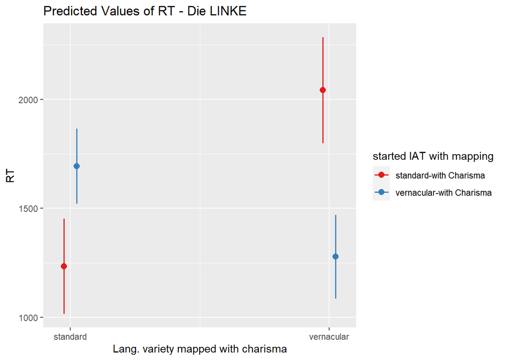

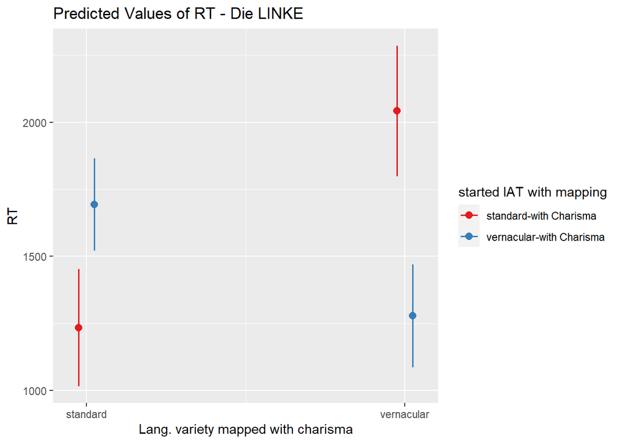

```
## Linear mixed model fit by REML. t-tests use Satterthwaite's method [
## lmerModLmerTest]
## Formula: penal_RTs ~ charisma_lang_var * voting_behaviour * start_iat +
##     trialcount + age + leadership_lang_var + (charisma_lang_var |
##     bilendi_id) + (start_iat | stimulus_ID)
##    Data: Four_Out
## Control: lmerControl(optimizer = "bobyqa", optCtrl = list(maxfun = 2e+05))
##
## REML criterion at convergence: 1003593
##
## Scaled residuals:
##     Min      1Q  Median      3Q     Max
## -6.2849 -0.6198 -0.1215  0.5499 13.5396
##
## Random effects:
##  Groups      Name                              Variance Std.Dev. Corr
##  bilendi_id  (Intercept)                       164969   406.16
##              charisma_lang_varvernacular       112062   334.76   -0.25
##  stimulus_ID (Intercept)                        11728   108.30
##              start_iatvernacular-with Charisma   1063    32.61   -0.05
##  Residual                                      326950   571.80
## Number of obs: 64365, groups:  bilendi_id, 537; stimulus_ID, 303
##
## Fixed effects:
##                                                                                             Estimate
## (Intercept)                                                                                1852.4701
## charisma_lang_varvernacular                                                                 659.0373
## voting_behaviourDIE LINKE                                                                  -166.8749
## voting_behaviourCDU/CSU                                                                    -109.7211
## voting_behaviourGRüNE                                                                         5.5994
## voting_behaviourFDP                                                                        -179.6895
## voting_behaviourAfD                                                                        -150.1658
## voting_behaviourandere                                                                     -200.3974
## voting_behaviourinvalid                                                                    -114.2246
## voting_behaviourNichtwähler                                                                 -99.1233
## voting_behaviourno_answer                                                                   -38.2698
## start_iatvernacular-with Charisma                                                           332.2214
## trialcount                                                                                   -5.7766
## age                                                                                           4.6777
## leadership_lang_var2                                                                         64.4530
```

[output cut: 235 more lines]

```
## voting_behaviourandere:start_iatvernacular-with Charisma
## voting_behaviourinvalid:start_iatvernacular-with Charisma
## voting_behaviourNichtwähler:start_iatvernacular-with Charisma                             .
## voting_behaviourno_answer:start_iatvernacular-with Charisma
## charisma_lang_varvernacular:voting_behaviourDIE LINKE:start_iatvernacular-with Charisma
## charisma_lang_varvernacular:voting_behaviourCDU/CSU:start_iatvernacular-with Charisma
## charisma_lang_varvernacular:voting_behaviourGRüNE:start_iatvernacular-with Charisma
## charisma_lang_varvernacular:voting_behaviourFDP:start_iatvernacular-with Charisma
## charisma_lang_varvernacular:voting_behaviourAfD:start_iatvernacular-with Charisma
## charisma_lang_varvernacular:voting_behaviourandere:start_iatvernacular-with Charisma
## charisma_lang_varvernacular:voting_behaviourinvalid:start_iatvernacular-with Charisma     *
## charisma_lang_varvernacular:voting_behaviourNichtwähler:start_iatvernacular-with Charisma
## charisma_lang_varvernacular:voting_behaviourno_answer:start_iatvernacular-with Charisma
## ---
## Signif. codes:  0 '***' 0.001 '**' 0.01 '*' 0.05 '.' 0.1 ' ' 1
```

```
##
## Correlation matrix not shown by default, as p = 43 > 12.
## Use print(x, correlation=TRUE)  or
##     vcov(x)        if you need it
```

```
## Linear mixed model fit by REML. t-tests use Satterthwaite's method [
## lmerModLmerTest]
## Formula: penal_RTs ~ charisma_lang_var * voting_behaviour * start_iat +
##     trialcount + age + leadership_lang_var + (charisma_lang_var |
##     bilendi_id) + (start_iat | stimulus_ID)
##    Data: Four_Out
## Control: lmerControl(optimizer = "bobyqa", optCtrl = list(maxfun = 2e+05))
##
## REML criterion at convergence: 1003593
##
## Scaled residuals:
##     Min      1Q  Median      3Q     Max
## -6.2849 -0.6198 -0.1215  0.5499 13.5396
##
## Random effects:
##  Groups      Name                              Variance Std.Dev. Corr
##  bilendi_id  (Intercept)                       164968   406.16
##              charisma_lang_varvernacular       112062   334.76   -0.25
##  stimulus_ID (Intercept)                        11728   108.30
##              start_iatvernacular-with Charisma   1063    32.61   -0.05
##  Residual                                      326950   571.80
## Number of obs: 64365, groups:  bilendi_id, 537; stimulus_ID, 303
##
## Fixed effects:
##                                                                                           Estimate
## (Intercept)                                                                              1753.3468
## charisma_lang_varvernacular                                                               496.4483
## voting_behaviourSPD                                                                        99.1233
## voting_behaviourDIE LINKE                                                                 -67.7517
## voting_behaviourCDU/CSU                                                                   -10.5978
## voting_behaviourGRüNE                                                                     104.7227
## voting_behaviourFDP                                                                       -80.5662
## voting_behaviourAfD                                                                       -51.0425
## voting_behaviourandere                                                                   -101.2741
## voting_behaviourinvalid                                                                   -15.1013
## voting_behaviourno_answer                                                                  60.8535
## start_iatvernacular-with Charisma                                                         631.8752
## trialcount                                                                                 -5.7766
## age                                                                                         4.6777
## leadership_lang_var2                                                                       64.4530
```

[output cut: 235 more lines]

```
## voting_behaviourAfD:start_iatvernacular-with Charisma
## voting_behaviourandere:start_iatvernacular-with Charisma
## voting_behaviourinvalid:start_iatvernacular-with Charisma
## voting_behaviourno_answer:start_iatvernacular-with Charisma
## charisma_lang_varvernacular:voting_behaviourSPD:start_iatvernacular-with Charisma
## charisma_lang_varvernacular:voting_behaviourDIE LINKE:start_iatvernacular-with Charisma .
## charisma_lang_varvernacular:voting_behaviourCDU/CSU:start_iatvernacular-with Charisma
## charisma_lang_varvernacular:voting_behaviourGRüNE:start_iatvernacular-with Charisma
## charisma_lang_varvernacular:voting_behaviourFDP:start_iatvernacular-with Charisma
## charisma_lang_varvernacular:voting_behaviourAfD:start_iatvernacular-with Charisma
## charisma_lang_varvernacular:voting_behaviourandere:start_iatvernacular-with Charisma
## charisma_lang_varvernacular:voting_behaviourinvalid:start_iatvernacular-with Charisma
## charisma_lang_varvernacular:voting_behaviourno_answer:start_iatvernacular-with Charisma
## ---
## Signif. codes:  0 '***' 0.001 '**' 0.01 '*' 0.05 '.' 0.1 ' ' 1
```

```
##
## Correlation matrix not shown by default, as p = 43 > 12.
## Use print(x, correlation=TRUE)  or
##     vcov(x)        if you need it
```